# FOOKAIYAN33085625

Foo Kai Yan

2024-04-19

> Student Name: Foo Kai Yan

> Student ID: 33085625

> Student Email: kfoo0012@student.monash.edu

## Statement: Generative AI was used in this assignment

- ChatGPT was used to help to retify an error in generating barchart by providing potential errors and solution. Prompt used was the error message shown after code has been runned. Output was how the code was modified to change and add dataframe before the barchart was generated.
- BingAI was used to bring an idea to code. Prompt used was to combine 2 columns described to the AI as an example and to combine the data in the cells under the columns to be within only 1 cell of a new column. Output was an example code.
- ChatGPT was used to find on how t-value will affect the confidence of the coefficient as a predictor. Prompt used was ‘how t-value is used to get the best predictor’. Output: Generally, any t-value greater than +2 or less than - 2 is acceptable. The higher the t-value, the greater the confidence we have in the coefficient as a predictor. Low t-values are indications of low reliability of the predictive power of that coefficient.

### Set working directory

```r
setwd("C:/Monash/FIT3152")
```

### Install and load the libraries used

```r
library(ggplot2)
library(dplyr)
library(tidyr)
library(factoextra)
library(ggpubr)
library(corrplot)
library(reshape)
```

### Load data in PsyCoronaBaselineExtract.csv

```r
rm(list = ls())
set.seed(33085625)
cvbase = read.csv("PsyCoronaBaselineExtract.csv", header = TRUE)
cvbase <- cvbase[sample(nrow(cvbase), 40000), ] # 40000 rows
```

### Basic pre-processing and descriptive analysis for the corona dataset

```r
dim(cvbase)
```

```
## [1] 40000    52
```

There is a total of 40,000 rows and 52 columns present in the dataset.

```r
names(cvbase)
```

```
##  [1] "employstatus_1"      "employstatus_2"      "employstatus_3"
##  [4] "employstatus_4"      "employstatus_5"      "employstatus_6"
##  [7] "employstatus_7"      "employstatus_8"      "employstatus_9"
## [10] "employstatus_10"     "isoFriends_inPerson" "isoOthPpl_inPerson"
## [13] "isoFriends_online"   "isoOthPpl_online"    "lone01"
## [16] "lone02"              "lone03"              "happy"
## [19] "lifeSat"             "MLQ"                 "bor01"
## [22] "bor02"               "bor03"               "consp01"
## [25] "consp02"             "consp03"             "rankOrdLife_1"
## [28] "rankOrdLife_2"       "rankOrdLife_3"       "rankOrdLife_4"
## [31] "rankOrdLife_5"       "rankOrdLife_6"       "c19perBeh01"
## [34] "c19perBeh02"         "c19perBeh03"         "c19RCA01"
## [37] "c19RCA02"            "c19RCA03"            "coronaClose_1"
## [40] "coronaClose_2"       "coronaClose_3"       "coronaClose_4"
## [43] "coronaClose_5"       "coronaClose_6"       "gender"
## [46] "age"                 "edu"                 "coded_country"
## [49] "c19ProSo01"          "c19ProSo02"          "c19ProSo03"
## [52] "c19ProSo04"
```

The 52 variables included in the dataset are employstatus_1, employstatus_2, employstatus_3, employstatus_4, employstatus_5, employstatus_6, employstatus_7, employstatus_8, employstatus_9, employstatus_10, isoFriends_inPerson, isoOthPpl_inPerson, isoFriends_online, isoOthPpl_online, lone01, lone02, lone03, happy, lifeSat, MLQ, bor01, bor02, bor03, consp01, consp02, consp03, rankOrdLife_1, rankOrdLife_2, rankOrdLife_3, rankOrdLife_4, rankOrdLife_5, rankOrdLife_6, c19perBeh01, c19perBeh02, c19perBeh03, c19RCA01, c19RCA02, c19RCA03, coronaClose_1, coronaClose_2, coronaClose_3, coronaClose_4, coronaClose_5, coronaClose_6, gender, age, edu, coded_country, c19ProSo01, c19ProSo02, c19ProSo03 and c19ProSo04.

```r
# Summary is used to obtain basic summary of each column present in the dataset 'cvbase'
# summary(cvbase)
# str(cvbase)
# The commented code above has been run in appendix section
```

From the code above, we can see that there is some missing values (“NA”) present in the dataset.

Most missing values are found in the columns employstatus_1, employstatus_2, employstatus_3, employstatus_4, employstatus_5, employstatus_6, employstatus_7, employstatus_8, employstatus_9 and employstatus_10 as these few columns ask on the concept of the employment status of the participants. Each options represents different employment status the participants might be in. Participants might only choose 1 of the many options provided even though they are allowed to choose multiple.

The Corona Proximity concept columns consisted of coronaClose_1, coronaClose_2, coronaClose_3, coronaClose_4, coronaClose_5 and coronaClose_6 which is also where the majority of the missing values are found in the dataset. These few columns ask the participants on whether they know people who have corona virus and each option represents different groups of people that have the corona virus and also a choice on not knowing anyone who have the corona virus.

Most of the responses is numerical except for rankOrdLife_1, rankOrdLife_2, rankOrdLife_3, rankOrdLife_4, rankOrdLife_5 and rankOrdLife_6 which responses came in alphabets and also coded_country which is the participants response on the country they currently live in or the country they spent most of their time in.

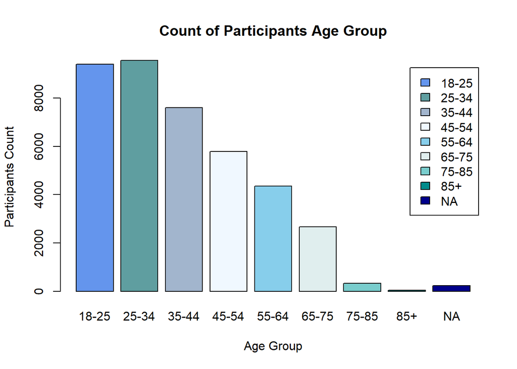

```r
participants_age = cvbase %>% group_by(age) %>% summarise(COUNT = n())
participants_age <- as.data.frame(participants_age, row.names = NULL, optional = FALSE)
participants_age_barchart = participants_age$COUNT
names(participants_age_barchart) <- c("18-25", "25-34", "35-44", "45-54", "55-64", "65-75", "75-85", "85+", "NA")
barplot(participants_age_barchart, main = "Count of Participants Age Group", xlab = "Age Group", ylab = "Participants Count", col = c("cornflowerblue", "cadetblue", "lightsteelblue3", "aliceblue", "skyblue", "azure2", "darkslategray3", "darkcyan", "darkblue"), border = "black", legend=TRUE)
```

The code above produce a bar chart that displayed the age range of the participants. From the bar chart, we can see that most participants are at the age range os 25-34 but the age range 18-25 is also quite high. This shows that most participants are teenagers or young adults and these people are the people that mostly spent their time on their devices.

```r
# Add one new column to the dataset named employment_status
# If employstatus_1 then under employment_status column put a 1
# If employstatus_1 and employstatus_2 then under employment_status column put 1, 2
# Once done, remove the columns for employstatus_1, employstatus_2, employstatus_3, employstatus_4, employstatus_5, employstatus_6, employstatus_7, employstatus_8, employstatus_9 and employstatus_10

# Adding the new column and populate it
employment_columns <- c("employstatus_1", "employstatus_2", "employstatus_3", "employstatus_4", "employstatus_5", "employstatus_6", "employstatus_7", "employstatus_8", "employstatus_9", "employstatus_10")
cvbase$employment_status <- NA
cvbase$employment_status <- apply(cvbase[, employment_columns], 1, function(row) {
  not_na <- which(!is.na(row))
  if (length(not_na) > 0) {
    paste(not_na, collapse = ", ")
  } else {
    NA
  }
})
head(cvbase$employment_status)
```

```
## [1] "4"  "9"  "9"  "3"  "10" "2"
```

```r
# Removing the columns
cvbase = subset(cvbase, select = -c(employstatus_1, employstatus_2, employstatus_3, employstatus_4, employstatus_5, employstatus_6, employstatus_7, employstatus_8, employstatus_9, employstatus_10))
```

```r
# Add one new column to the dataset named corona_close
# If coronaClose_1 then under corona_close column put a 1
# If coronaClose_1 and coronaClose_2 then under corona_close column put 1, 2
# Once done, remove the columns for coronaClose_1, coronaClose_2, coronaClose_3, coronaClose_4, coronaClose_5 and coronaClose_6

# Adding the new column and populate it
close_contact_column <- c("coronaClose_1", "coronaClose_2", "coronaClose_3", "coronaClose_4", "coronaClose_5", "coronaClose_6")
cvbase$corona_close <- NA
cvbase$corona_close <- apply(cvbase[, close_contact_column], 1, function(row) {
  not_na <- which(!is.na(row))
  if (length(not_na) > 0) {
    paste(not_na, collapse = ", ")
  } else {
    NA
  }
})
head(cvbase$corona_close)
```

```
## [1] "6" "6" "6" "6" "5" "6"
```

```r
# Removing the columns
cvbase = subset(cvbase, select = -c(coronaClose_1, coronaClose_2, coronaClose_3, coronaClose_4, coronaClose_5, coronaClose_6))
```

## Focus country by Student ID 33085625 is Malaysia

```r
# Group 1 --> Participants from Malaysia
msia = cvbase %>% filter(coded_country == "Malaysia")
dim(msia)
```

```
## [1] 548  38
```

```r
# Group 2 --> Participants not from Malaysia
not_msia = cvbase %>% filter(coded_country != "Malaysia")
dim(not_msia)
```

```
## [1] 39452    38
```

After filtering the newly processed dataset, another filter is applied to pinpoint the responses has its coded_country listed as Malaysia or not Malaysia. Not Malaysia includes all the other countries that is not named Malaysia like Japan, Russia and more.

After future filtering, it is known that there is 548 rows and 38 columns for responses with focus country listed as Malaysia. Whereas on the other hand, there is 39452 rows and 38 columns for responses with focus country not listed as Malaysia.

```r
# head() is used to get a glimpse of the data
covid19ProSo <- cvbase[, c("coded_country", "c19ProSo01", "c19ProSo02", "c19ProSo03", "c19ProSo04")]
head(covid19ProSo)
```

|  | coded_country | c19ProSo01 | c19ProSo02 | c19ProSo03 | c19ProSo04 |
| --- | --- | --- | --- | --- | --- |
| 24995 | Greece | 2 | 0 | 2 | -2 |
| 47631 | Egypt | 1 | 1 | 1 | 1 |
| 33923 | Romania | 3 | 0 | 0 | 3 |
| 4530 | Italy | 0 | 0 | -1 | 0 |
| 3978 | China | 3 | 3 | 3 | 2 |
| 36761 | Netherlands | 2 | -2 | 2 | 3 |

```r
prosocial_msia <- covid19ProSo[covid19ProSo$coded_country == "Malaysia", ]
head(prosocial_msia)
```

|  | coded_country | c19ProSo01 | c19ProSo02 | c19ProSo03 | c19ProSo04 |
| --- | --- | --- | --- | --- | --- |
| 24272 | Malaysia | 0 | 0 | 0 | 1 |
| 52597 | Malaysia | 0 | 0 | 0 | 3 |
| 28793 | Malaysia | 0 | 2 | 1 | 1 |
| 43389 | Malaysia | 2 | 3 | 0 | 0 |
| 54798 | Malaysia | 1 | 1 | 0 | 2 |
| 301 | Malaysia | -3 | 2 | 2 | 2 |

First, before filtering the pro-social attitudes of the participants according to country, the columns that store participants’ country and their pro-social attitudes is moved to a new dataframe ‘covid19ProSo’ for easy view of the participants’ responses. This is also to not touch on the newly processed dataset to prevent any mistakes done that would change the original dataset.

prosocial_msia stores the Malaysian participants’ pros-social attitudes responses.

```r
covid19ProSo <- cvbase[, c("coded_country", "c19ProSo01", "c19ProSo02", "c19ProSo03", "c19ProSo04")]

prosocial_not_msia <- covid19ProSo[covid19ProSo$coded_country != "Malaysia", ]
head(prosocial_not_msia)
```

|  | coded_country | c19ProSo01 | c19ProSo02 | c19ProSo03 | c19ProSo04 |
| --- | --- | --- | --- | --- | --- |
| 24995 | Greece | 2 | 0 | 2 | -2 |
| 47631 | Egypt | 1 | 1 | 1 | 1 |
| 33923 | Romania | 3 | 0 | 0 | 3 |
| 4530 | Italy | 0 | 0 | -1 | 0 |
| 3978 | China | 3 | 3 | 3 | 2 |
| 36761 | Netherlands | 2 | -2 | 2 | 3 |

prosocial_not_msia stores the non-Malaysian participants’ pros-social attitudes responses.

```r
# Malaysia Pro-Social Attitude
paste("Malaysia Pro-Social Attitude")
```

```
## [1] "Malaysia Pro-Social Attitude"
```

```r
# msia c19ProSo01
paste("c19ProSo01")
```

```
## [1] "c19ProSo01"
```

```r
c19ProSo01_count_values <- table(prosocial_msia$c19ProSo01)
c19ProSo01_count_values
```

```
##
##  -3  -2  -1   0   1   2   3
##  10   8  18  88 130 213  80
```

```r
# msia c19ProSo02
paste("c19ProSo02")
```

```
## [1] "c19ProSo02"
```

```r
c19ProSo02_count_values <- table(prosocial_msia$c19ProSo02)
c19ProSo02_count_values
```

```
##
##  -3  -2  -1   0   1   2   3
##  10   8  11  68 116 221 113
```

```r
# msia c19ProSo03
paste("c19ProSo03")
```

```
## [1] "c19ProSo03"
```

```r
c19ProSo03_count_values <- table(prosocial_msia$c19ProSo03)
c19ProSo03_count_values
```

```
##
##  -3  -2  -1   0   1   2   3
##   7  15  36 127 152 142  68
```

```r
# msia c19ProSo04
paste("c19ProSo04")
```

```
## [1] "c19ProSo04"
```

```r
c19ProSo04_count_values <- table(prosocial_msia$c19ProSo04)
c19ProSo04_count_values
```

```
##
##  -3  -2  -1   0   1   2   3
##   7  28  23 100 114 166 109
```

```r
# Non-Malaysia Pro-Social Attitude
paste("Non-Malaysia Pro-Social Attitude")
```

```
## [1] "Non-Malaysia Pro-Social Attitude"
```

```r
# not msia c19ProSo01
paste("c19ProSo01")
```

```
## [1] "c19ProSo01"
```

```r
c19ProSo01_count_values <- table(prosocial_not_msia$c19ProSo01)
c19ProSo01_count_values
```

```
##
##    -3    -2    -1     0     1     2     3
##  1173  1996  2397  7482  9742 11552  4982
```

```r
# not msia c19ProSo02
paste("c19ProSo02")
```

```
## [1] "c19ProSo02"
```

```r
c19ProSo02_count_values <- table(prosocial_not_msia$c19ProSo02)
c19ProSo02_count_values
```

```
##
##    -3    -2    -1     0     1     2     3
##  2111  3300  2942  7982  8517 10065  4402
```

```r
# not msia c19ProSo03
paste("c19ProSo03")
```

```
## [1] "c19ProSo03"
```

```r
c19ProSo03_count_values <- table(prosocial_not_msia$c19ProSo03)
c19ProSo03_count_values
```

```
##
##   -3   -2   -1    0    1    2    3
## 2162 3766 3625 8445 8251 8531 4524
```

```r
# not msia c19ProSo04
paste("c19ProSo04")
```

```
## [1] "c19ProSo04"
```

```r
c19ProSo04_count_values <- table(prosocial_not_msia$c19ProSo04)
c19ProSo04_count_values
```

```
##
##    -3    -2    -1     0     1     2     3
##  1228  1891  2000  5375  7395 11755  9659
```

From the code above, we can see that there is a total of 7 kinds of responses from the range of -3 to 3. The 7 types of responses are Strongly disagree, Disagree, Somewhat disagree, Neither agree nor disagree, Somewhat agree, Agree, Strongly agree. If the response is -3, then the response is “Strongly disagree”. If the response is -2, then the response is “Disagree”. If the response is -1, then the response is “Somewhat disagree”. If the response is 0, then the response is “Neither agree nor disagree”. If the response is 1, then the response is “Somewhat agree”. If the response is 2, then the response is “Agree”. If the response is 3, then the response is “Strongly agree”.

We can see that from c19ProSo01 column, responses from Malaysia is mostly at ‘2’ where 213 “Agree” to the statement that “I am willing to help others who suffer from coronavirus.” We can also see that responses by participants not from Malaysia also mostly chose ‘2’ whereby the 11552 participants also “Agree” to the statement that “I am willing to help others who suffer from coronavirus.”

Next, it would be the c19ProSo02 column. 221 participants from Malaysia responded ‘2’ which is that they “Agree” to the statement that “I am willing to make donations to help others that suffer from coronavirus.” We can also see that responses by participants not from Malaysia also mostly chose ‘2’ whereby the 10065 participants also “Agree” to the statement that “I am willing to make donations to help others that suffer from coronavirus.”

From the c19ProSo03 column, 152 participants from Malaysia responded ‘1’ where they “Somewhat agree” to the statement that “I am willing to protect vulnerable groups from coronavirus even at my own expense.” There is a slight difference here whereby 8531 participants not from Malaysia responded that they “Agree” to the statement “I am willing to protect vulnerable groups from coronavirus even at my own expense.” But there are also a high number of participants not from Malaysia responded that they “Neither agree nor disagree” to the same statement.

Last but not least, the c19ProSo04 column. 166 participants from Malaysia responded ‘2’ which is that they “Agree” to the statement that “I am willing to make personal sacrifices to prevent the spread of coronavirus.” Most of the non-Malaysian participants which is 11755 participants also have the same response.

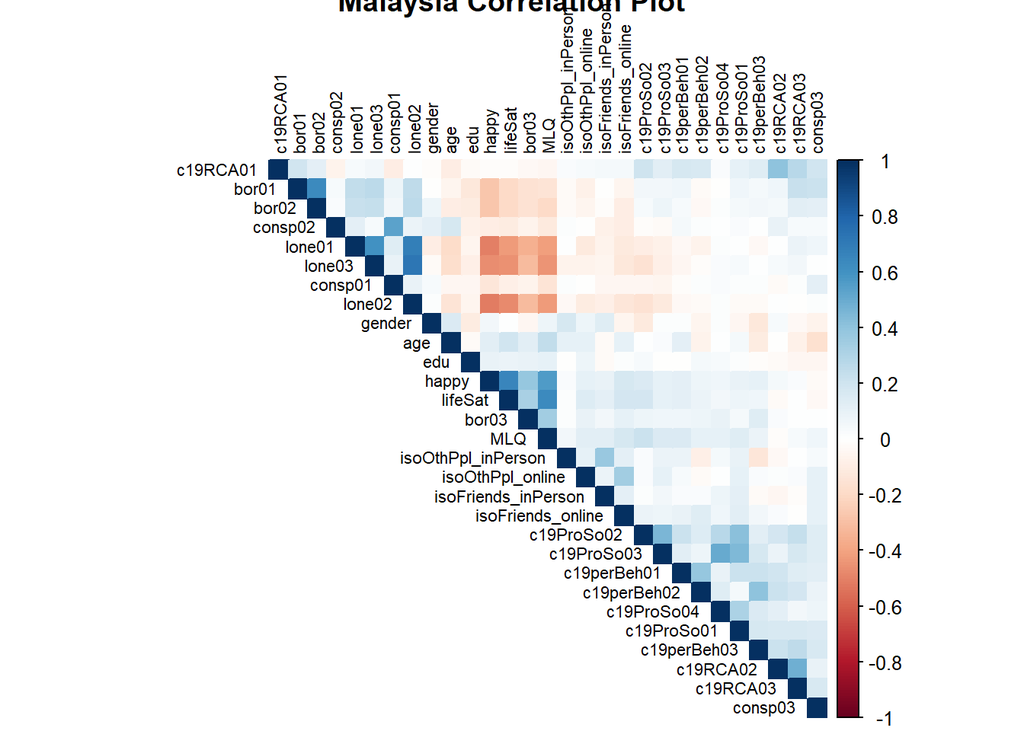

```r
msia_corr <- msia
msia_corr = subset(msia_corr, select = -c(rankOrdLife_1, rankOrdLife_2, rankOrdLife_3, rankOrdLife_4, rankOrdLife_5, rankOrdLife_6, coded_country, employment_status, corona_close))

# Compute the correlation matrix
cor_matrix <- cor(msia_corr, use = "complete.obs")  # Omit NA values

# Create a correlation plot
corrplot(cor_matrix, method = "color", order = "AOE", tl.cex = 0.7, tl.col = "black",
         title = "Malaysia Correlation Plot", type = "upper")

# Add a legend
legend("bottomleft", legend = c("Low correlation", "High correlation"),
       fill = c("white", "blue"), bty = "n", cex = 0.8, title = "Correlation Level")
```

Above presents the correlation plot for each of the predictors for Malaysia.

```r
str(msia)
```

```
## 'data.frame':    548 obs. of  38 variables:
##  $ isoFriends_inPerson: int  0 0 0 0 0 0 0 0 0 1 ...
##  $ isoOthPpl_inPerson : int  0 0 1 1 1 0 2 0 0 1 ...
##  $ isoFriends_online  : int  4 0 7 7 0 3 1 7 5 5 ...
##  $ isoOthPpl_online   : int  1 1 0 0 0 0 3 4 3 6 ...
##  $ lone01             : int  2 1 1 1 4 3 2 2 3 3 ...
##  $ lone02             : int  1 1 1 1 5 1 2 2 3 2 ...
##  $ lone03             : int  1 1 1 1 4 1 2 2 3 1 ...
##  $ happy              : int  7 7 9 6 3 3 7 5 6 7 ...
##  $ lifeSat            : int  5 4 5 5 2 2 4 4 4 5 ...
##  $ MLQ                : int  2 3 2 3 -2 -2 1 0 2 2 ...
##  $ bor01              : int  1 -2 3 -2 3 3 1 2 1 3 ...
##  $ bor02              : int  -1 -2 2 -2 2 3 0 -2 1 2 ...
##  $ bor03              : int  1 2 1 0 1 1 1 0 -2 2 ...
##  $ consp01            : int  5 10 4 5 7 10 6 NA 9 3 ...
```

[output cut: 24 more lines]

```r
msia_q2b <- msia
msia_q2b = subset(msia_q2b, select = -c(rankOrdLife_1, rankOrdLife_2, rankOrdLife_3, rankOrdLife_4, rankOrdLife_5, rankOrdLife_6, coded_country, employment_status, corona_close))


# Best predictor for c19ProSo01
# Fit the linear model for c19ProSo01
c19ProSo01_best <- lm(c19ProSo01 ~., data = msia_q2b)
# Extract coefficients and p-values
c19ProSo01_best_summary <- summary(c19ProSo01_best)$coefficients
# Find significant predictors (p-value < 0.05)
c19ProSo01_significant_predictors <- c19ProSo01_best_summary[c19ProSo01_best_summary[, "Pr(>|t|)"] < 0.05, ]
# Sort predictors by absolute coefficient magnitude (significant)
c19ProSo01_strongest_predictors <- c19ProSo01_significant_predictors[order(abs(c19ProSo01_significant_predictors[, "Pr(>|t|)"]), decreasing = FALSE), ]
# Display the 2 highest/strongest predictors (those with ***)
c19ProSo01_strongest_predictors[1:2, ]
```

```
##             Estimate Std. Error  t value     Pr(>|t|)
## c19ProSo02 0.2559605 0.04819536 5.310895 1.723252e-07
## c19ProSo03 0.2469945 0.04894136 5.046745 6.551011e-07
```

```r
# Get the R-Squared value
summary(c19ProSo01_best)
```

```
##
## Call:
## lm(formula = c19ProSo01 ~ ., data = msia_q2b)
##
## Residuals:
##     Min      1Q  Median      3Q     Max
## -4.5360 -0.4580  0.1606  0.6137  3.3645
##
## Coefficients:
##                      Estimate Std. Error t value Pr(>|t|)
## (Intercept)         -0.578096   0.569329  -1.015  0.31047
## isoFriends_inPerson  0.052118   0.023262   2.240  0.02555 *
## isoOthPpl_inPerson   0.011132   0.028188   0.395  0.69310
## isoFriends_online    0.030434   0.023507   1.295  0.19611
## isoOthPpl_online     0.014629   0.021591   0.678  0.49840
## lone01               0.008974   0.068040   0.132  0.89513
## lone02              -0.019923   0.072058  -0.276  0.78231
## lone03               0.173299   0.068569   2.527  0.01184 *
## happy                0.033681   0.039496   0.853  0.39425
## lifeSat             -0.046903   0.063441  -0.739  0.46010
## MLQ                  0.050256   0.049029   1.025  0.30590
## bor01                0.005426   0.037210   0.146  0.88413
## bor02               -0.006778   0.037889  -0.179  0.85811
## bor03               -0.006643   0.037946  -0.175  0.86112
## consp01              0.016603   0.024270   0.684  0.49426
## consp02              0.007456   0.027997   0.266  0.79011
## consp03              0.018221   0.023081   0.789  0.43028
## c19perBeh01          0.178897   0.060762   2.944  0.00341 **
## c19perBeh02         -0.310739   0.104257  -2.981  0.00303 **
## c19perBeh03          0.112181   0.053571   2.094  0.03682 *
## c19RCA01            -0.036373   0.041648  -0.873  0.38295
## c19RCA02             0.136828   0.083725   1.634  0.10291
## c19RCA03             0.002407   0.049751   0.048  0.96143
## gender              -0.111604   0.119466  -0.934  0.35071
## age                  0.035402   0.044815   0.790  0.42996
## edu                  0.027532   0.046272   0.595  0.55214
## c19ProSo02           0.255961   0.048195   5.311 1.72e-07 ***
## c19ProSo03           0.246995   0.048941   5.047 6.55e-07 ***
## c19ProSo04           0.072733   0.044153   1.647  0.10020
## ---
## Signif. codes:  0 '***' 0.001 '**' 0.01 '*' 0.05 '.' 0.1 ' ' 1
##
## Residual standard error: 1.062 on 447 degrees of freedom
##   (72 observations deleted due to missingness)
## Multiple R-squared:  0.3358, Adjusted R-squared:  0.2941
## F-statistic: 8.069 on 28 and 447 DF,  p-value: < 2.2e-16
```

```r
# Best predictor for c19ProSo02
c19ProSo02_best <- lm(c19ProSo02 ~., data = msia_q2b)
c19ProSo02_best_summary <- summary(c19ProSo02_best)$coefficients
c19ProSo02_significant_predictors <- c19ProSo02_best_summary[c19ProSo02_best_summary[, "Pr(>|t|)"] < 0.05, ]
c19ProSo02_strongest_predictors <- c19ProSo02_significant_predictors[order(abs(c19ProSo02_significant_predictors[, "Pr(>|t|)"]), decreasing = FALSE), ]
c19ProSo02_strongest_predictors[1:2, ]
```

```
##             Estimate Std. Error  t value     Pr(>|t|)
## c19ProSo03 0.2532347 0.04637006 5.461167 7.863349e-08
## c19ProSo01 0.2318894 0.04366296 5.310895 1.723252e-07
```

```r
summary(c19ProSo02_best)
```

```
##
## Call:
## lm(formula = c19ProSo02 ~ ., data = msia_q2b)
##
## Residuals:
##     Min      1Q  Median      3Q     Max
## -4.3334 -0.4782  0.1387  0.5467  3.0780
##
## Coefficients:
##                       Estimate Std. Error t value Pr(>|t|)
## (Intercept)          5.843e-01  5.418e-01   1.078  0.28143
## isoFriends_inPerson -2.080e-02  2.224e-02  -0.935  0.35014
## isoOthPpl_inPerson  -3.295e-03  2.683e-02  -0.123  0.90232
## isoFriends_online   -6.813e-05  2.242e-02  -0.003  0.99758
## isoOthPpl_online    -1.893e-02  2.054e-02  -0.922  0.35716
## lone01               7.366e-03  6.476e-02   0.114  0.90950
## lone02              -4.826e-03  6.859e-02  -0.070  0.94394
## lone03              -1.347e-01  6.542e-02  -2.059  0.04003 *
## happy               -6.661e-03  3.762e-02  -0.177  0.85955
## lifeSat              6.880e-02  6.033e-02   1.140  0.25474
## MLQ                  6.328e-02  4.663e-02   1.357  0.17537
## bor01                9.240e-04  3.542e-02   0.026  0.97920
## bor02                2.553e-02  3.604e-02   0.708  0.47915
## bor03               -1.594e-02  3.611e-02  -0.442  0.65903
## consp01             -8.978e-03  2.311e-02  -0.389  0.69781
## consp02              1.299e-02  2.664e-02   0.488  0.62611
## consp03              4.767e-03  2.198e-02   0.217  0.82841
## c19perBeh01          8.469e-02  5.826e-02   1.454  0.14669
## c19perBeh02          1.212e-01  1.001e-01   1.211  0.22639
## c19perBeh03         -9.485e-02  5.104e-02  -1.858  0.06379 .
## c19RCA01             9.213e-02  3.944e-02   2.336  0.01992 *
## c19RCA02             4.668e-02  7.990e-02   0.584  0.55938
## c19RCA03             9.665e-02  4.713e-02   2.051  0.04089 *
## gender              -2.966e-01  1.130e-01  -2.625  0.00895 **
## age                 -2.868e-02  4.266e-02  -0.672  0.50174
## edu                  6.858e-03  4.406e-02   0.156  0.87637
## c19ProSo01           2.319e-01  4.366e-02   5.311 1.72e-07 ***
## c19ProSo03           2.532e-01  4.637e-02   5.461 7.86e-08 ***
## c19ProSo04           4.560e-02  4.210e-02   1.083  0.27927
## ---
## Signif. codes:  0 '***' 0.001 '**' 0.01 '*' 0.05 '.' 0.1 ' ' 1
##
## Residual standard error: 1.011 on 447 degrees of freedom
##   (72 observations deleted due to missingness)
## Multiple R-squared:  0.3549, Adjusted R-squared:  0.3145
## F-statistic: 8.782 on 28 and 447 DF,  p-value: < 2.2e-16
```

```r
# Best predictor for c19ProSo03
c19ProSo03_best <- lm(c19ProSo03 ~., data = msia_q2b)
c19ProSo03_best_summary <- summary(c19ProSo03_best)$coefficients
c19ProSo03_significant_predictors <- c19ProSo03_best_summary[c19ProSo03_best_summary[, "Pr(>|t|)"] < 0.05, ]
c19ProSo03_strongest_predictors <- c19ProSo03_significant_predictors[order(abs(c19ProSo03_significant_predictors[, "Pr(>|t|)"]), decreasing = FALSE), ]
c19ProSo03_strongest_predictors[1:2, ]
```

```
##             Estimate Std. Error  t value     Pr(>|t|)
## c19ProSo04 0.3753915 0.03765420 9.969445 2.846259e-21
## c19ProSo02 0.2469957 0.04522763 5.461167 7.863349e-08
```

```r
summary(c19ProSo03_best)
```

```
##
## Call:
## lm(formula = c19ProSo03 ~ ., data = msia_q2b)
##
## Residuals:
##     Min      1Q  Median      3Q     Max
## -3.1859 -0.4924  0.1367  0.5983  3.6586
##
## Coefficients:
##                      Estimate Std. Error t value Pr(>|t|)
## (Intercept)          0.497121   0.535282   0.929   0.3535
## isoFriends_inPerson -0.025947   0.021955  -1.182   0.2379
## isoOthPpl_inPerson   0.034794   0.026450   1.315   0.1890
## isoFriends_online   -0.012809   0.022131  -0.579   0.5630
## isoOthPpl_online     0.037022   0.020231   1.830   0.0679 .
## lone01              -0.033731   0.063940  -0.528   0.5981
## lone02              -0.067802   0.067665  -1.002   0.3169
## lone03              -0.037022   0.064892  -0.571   0.5686
## happy               -0.007895   0.037155  -0.212   0.8318
## lifeSat             -0.011119   0.059670  -0.186   0.8523
## MLQ                  0.007668   0.046141   0.166   0.8681
## bor01               -0.010007   0.034976  -0.286   0.7749
## bor02                0.045973   0.035552   1.293   0.1966
## bor03               -0.030996   0.035641  -0.870   0.3849
## consp01             -0.032628   0.022774  -1.433   0.1526
## consp02              0.006595   0.026318   0.251   0.8022
## consp03              0.016865   0.021697   0.777   0.4374
## c19perBeh01         -0.030532   0.057651  -0.530   0.5967
## c19perBeh02         -0.066186   0.098923  -0.669   0.5038
## c19perBeh03          0.086437   0.050439   1.714   0.0873 .
## c19RCA01             0.044679   0.039126   1.142   0.2541
## c19RCA02            -0.184843   0.078453  -2.356   0.0189 *
## c19RCA03             0.092406   0.046563   1.985   0.0478 *
## gender               0.106968   0.112296   0.953   0.3413
## age                  0.000315   0.042156   0.007   0.9940
## edu                 -0.031452   0.043488  -0.723   0.4699
## c19ProSo01           0.218254   0.043246   5.047 6.55e-07 ***
## c19ProSo02           0.246996   0.045228   5.461 7.86e-08 ***
## c19ProSo04           0.375391   0.037654   9.969  < 2e-16 ***
## ---
## Signif. codes:  0 '***' 0.001 '**' 0.01 '*' 0.05 '.' 0.1 ' ' 1
##
## Residual standard error: 0.9981 on 447 degrees of freedom
##   (72 observations deleted due to missingness)
## Multiple R-squared:  0.4445, Adjusted R-squared:  0.4097
## F-statistic: 12.78 on 28 and 447 DF,  p-value: < 2.2e-16
```

```r
# Best predictor for c19ProSo04
c19ProSo04_best <- lm(c19ProSo04 ~., data = msia_q2b)
c19ProSo04_best_summary <- summary(c19ProSo04_best)$coefficients
c19ProSo04_significant_predictors <- c19ProSo04_best_summary[c19ProSo04_best_summary[, "Pr(>|t|)"] < 0.05, ]
c19ProSo04_strongest_predictors <- c19ProSo04_significant_predictors[order(abs(c19ProSo04_significant_predictors[, "Pr(>|t|)"]), decreasing = FALSE), ]
c19ProSo04_strongest_predictors[1:2, ]
```

```
##              Estimate Std. Error   t value     Pr(>|t|)
## c19ProSo03  0.4845682 0.04860533  9.969445 2.846259e-21
## c19RCA03   -0.1187091 0.05283717 -2.246697 2.514670e-02
```

```r
summary(c19ProSo04_best)
```

```
##
## Call:
## lm(formula = c19ProSo04 ~ ., data = msia_q2b)
##
## Residuals:
##     Min      1Q  Median      3Q     Max
## -3.7859 -0.6533  0.1128  0.6938  2.9062
##
## Coefficients:
##                       Estimate Std. Error t value Pr(>|t|)
## (Intercept)         -0.9382774  0.6071262  -1.545   0.1229
## isoFriends_inPerson  0.0281572  0.0249473   1.129   0.2596
## isoOthPpl_inPerson  -0.0057822  0.0301085  -0.192   0.8478
## isoFriends_online    0.0139947  0.0251444   0.557   0.5781
## isoOthPpl_online    -0.0357561  0.0230089  -1.554   0.1209
## lone01               0.0663410  0.0726000   0.914   0.3613
## lone02               0.0448717  0.0769350   0.583   0.5600
## lone03               0.0791968  0.0736582   1.075   0.2829
## happy                0.0043484  0.0422156   0.103   0.9180
## lifeSat             -0.0056451  0.0677962  -0.083   0.9337
## MLQ                  0.0345365  0.0523988   0.659   0.5102
## bor01               -0.0141496  0.0397356  -0.356   0.7219
## bor02               -0.0092274  0.0404650  -0.228   0.8197
## bor03                0.0727636  0.0403811   1.802   0.0722 .
## consp01              0.0309582  0.0258924   1.196   0.2325
## consp02             -0.0144204  0.0298952  -0.482   0.6298
## consp03             -0.0008683  0.0246677  -0.035   0.9719
## c19perBeh01         -0.0385479  0.0654951  -0.589   0.5565
## c19perBeh02          0.2041366  0.1120322   1.822   0.0691 .
## c19perBeh03          0.0321575  0.0574736   0.560   0.5761
## c19RCA01            -0.0665195  0.0444068  -1.498   0.1348
## c19RCA02             0.1986267  0.0891923   2.227   0.0264 *
## c19RCA03            -0.1187091  0.0528372  -2.247   0.0251 *
## gender               0.1042333  0.1276198   0.817   0.4145
## age                  0.0009672  0.0478955   0.020   0.9839
## edu                  0.0413589  0.0493995   0.837   0.4029
## c19ProSo01           0.0829613  0.0503622   1.647   0.1002
## c19ProSo02           0.0574158  0.0530024   1.083   0.2793
## c19ProSo03           0.4845682  0.0486053   9.969   <2e-16 ***
## ---
## Signif. codes:  0 '***' 0.001 '**' 0.01 '*' 0.05 '.' 0.1 ' ' 1
##
## Residual standard error: 1.134 on 447 degrees of freedom
##   (72 observations deleted due to missingness)
## Multiple R-squared:  0.319,  Adjusted R-squared:  0.2764
## F-statistic: 7.478 on 28 and 447 DF,  p-value: < 2.2e-16
```

Due to some of the variables having data of not being non-numerical type, the non-numerical columns are removed so a linear regression model (lm) could be used to determine which of the variables are the best predictors by the number of * present at the most right-side as the more * there is on the rightmost side the more significant the variables are.

When the linear model was generated for c19ProSo01 there were more than 1 predictors and/or variables that have *** present so indices was used to get the top 2 best predictors and/or variables for each c19ProSo01, c19ProSo02, c19ProSo03, c19ProSo04. 2 best predictors was displayed as if only 1 was displayed, there will be no variable name shown at output.

For the focus country Malaysia, for c19ProSo03, the best predictor is c19ProSo04. c19ProSo04 is a better predictor than c19ProSo02 because its coefficient estimate is higher so it indicated that c19ProSo04 has a stronger impact on c19ProSo03 than c19ProSo02 does impact on c19ProSo03. The t-value for c19ProSo04 is higher than that for c19ProSo02 and a higher t value indicates that the greater the confidence in c19ProSo04 as a predictor than c19ProSo02.

For the focus country Malaysia, for c19ProSo04, the best predictor is c19ProSo03. c19ProSo03 is a better predictor than c19RCA03 because its coefficient estimate is higher so it indicated that c19ProSo03 has a stronger impact on c19ProSo04 than c19RCA03 does impact on c19ProSo04. The t-value for c19ProSo03 is higher than that for c19RCA03 and a higher t value indicates that the greater the confidence in c19ProSo04 as a predictor than c19RCA03.

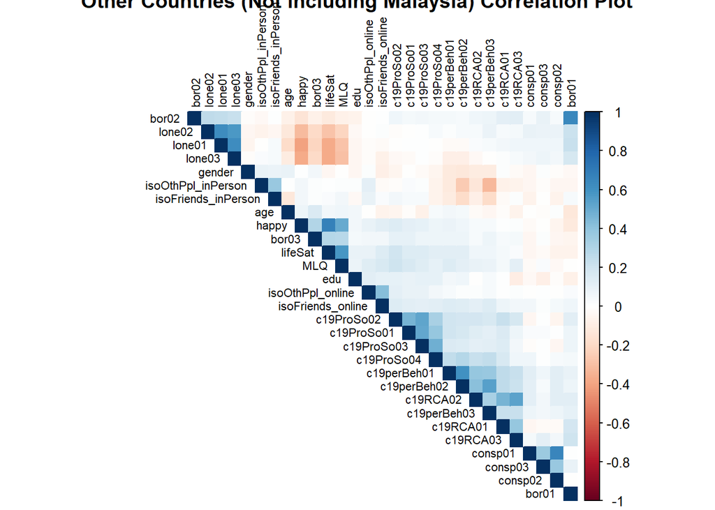

```r
not_msia_corr <- not_msia
not_msia_corr = subset(not_msia_corr, select = -c(rankOrdLife_1, rankOrdLife_2, rankOrdLife_3, rankOrdLife_4, rankOrdLife_5, rankOrdLife_6, coded_country, employment_status, corona_close))

# Compute the correlation matrix
cor_matrix <- cor(not_msia_corr, use = "complete.obs")  # Omit NA values

# Create a correlation plot
corrplot(cor_matrix, method = "color", order = "AOE", tl.cex = 0.7, tl.col = "black",
         title = "Other Countries (Not including Malaysia) Correlation Plot", type = "upper")

# Add a legend
legend("bottomleft", legend = c("Low correlation", "High correlation"),
       fill = c("white", "blue"), bty = "n", cex = 0.8, title = "Correlation Level")
```

```r
str(not_msia)
```

```
## 'data.frame':    39452 obs. of  38 variables:
##  $ isoFriends_inPerson: int  2 3 4 2 4 7 2 7 3 1 ...
##  $ isoOthPpl_inPerson : int  0 0 3 0 2 4 3 7 3 0 ...
##  $ isoFriends_online  : int  7 0 5 4 3 4 5 7 4 7 ...
##  $ isoOthPpl_online   : int  7 0 0 4 6 0 0 7 0 3 ...
##  $ lone01             : int  3 2 1 3 1 2 2 1 3 2 ...
##  $ lone02             : int  2 2 1 4 1 4 4 1 3 1 ...
##  $ lone03             : int  2 2 1 4 1 3 1 1 2 1 ...
##  $ happy              : int  1 6 10 7 8 2 7 7 6 8 ...
##  $ lifeSat            : int  1 4 6 4 6 2 5 4 4 4 ...
##  $ MLQ                : int  0 2 3 0 3 -2 1 1 -1 -1 ...
##  $ bor01              : int  0 2 -3 0 -2 -1 3 2 0 1 ...
##  $ bor02              : int  -1 1 -3 1 -2 -1 1 2 1 0 ...
##  $ bor03              : int  -1 -1 3 1 3 -1 2 -1 1 -1 ...
##  $ consp01            : int  10 5 8 7 NA 2 3 NA 10 4 ...
```

[output cut: 24 more lines]

```r
msia_q2c <- not_msia
msia_q2c = subset(msia_q2c, select = -c(rankOrdLife_1, rankOrdLife_2, rankOrdLife_3, rankOrdLife_4, rankOrdLife_5, rankOrdLife_6, coded_country, employment_status, corona_close))

# Best predictor for c19ProSo01
c19ProSo01_best <- lm(c19ProSo01 ~., data = msia_q2c)
c19ProSo01_best_summary <- summary(c19ProSo01_best)$coefficients
c19ProSo01_significant_predictors <- c19ProSo01_best_summary[c19ProSo01_best_summary[, "Pr(>|t|)"] < 0.05, ]
c19ProSo01_strongest_predictors <- c19ProSo01_significant_predictors[order(abs(c19ProSo01_significant_predictors[, "Pr(>|t|)"]), decreasing = FALSE), ]
c19ProSo02_strongest_predictors[1:2, ]
```

```
##             Estimate Std. Error  t value     Pr(>|t|)
## c19ProSo03 0.2532347 0.04637006 5.461167 7.863349e-08
## c19ProSo01 0.2318894 0.04366296 5.310895 1.723252e-07
```

```r
summary(c19ProSo01_best)
```

```
##
## Call:
## lm(formula = c19ProSo01 ~ ., data = msia_q2c)
##
## Residuals:
##     Min      1Q  Median      3Q     Max
## -5.7121 -0.6055  0.1400  0.7220  4.3658
##
## Coefficients:
##                      Estimate Std. Error t value Pr(>|t|)
## (Intercept)         -0.251897   0.055826  -4.512 6.44e-06 ***
## isoFriends_inPerson  0.003886   0.002907   1.337  0.18126
## isoOthPpl_inPerson   0.019609   0.003272   5.994 2.07e-09 ***
## isoFriends_online    0.011816   0.002918   4.049 5.15e-05 ***
## isoOthPpl_online     0.002497   0.002673   0.934  0.35011
## lone01               0.055512   0.007928   7.002 2.57e-12 ***
## lone02              -0.014326   0.006970  -2.055  0.03986 *
## lone03              -0.014190   0.007534  -1.884  0.05963 .
## happy                0.014078   0.004457   3.158  0.00159 **
## lifeSat             -0.019449   0.007690  -2.529  0.01144 *
## MLQ                  0.048934   0.005166   9.472  < 2e-16 ***
## bor01                0.010262   0.004471   2.295  0.02172 *
## bor02               -0.001008   0.004471  -0.226  0.82157
## bor03                0.024173   0.004162   5.808 6.39e-09 ***
## consp01              0.013665   0.003275   4.172 3.02e-05 ***
## consp02              0.004232   0.003439   1.231  0.21851
## consp03              0.005829   0.002597   2.245  0.02479 *
## c19perBeh01          0.075607   0.007499  10.083  < 2e-16 ***
## c19perBeh02          0.040660   0.008992   4.522 6.15e-06 ***
## c19perBeh03         -0.036014   0.005306  -6.788 1.16e-11 ***
## c19RCA01             0.020596   0.004023   5.120 3.08e-07 ***
## c19RCA02             0.005333   0.006414   0.831  0.40574
## c19RCA03            -0.022928   0.004277  -5.360 8.35e-08 ***
## gender               0.069741   0.012957   5.383 7.39e-08 ***
## age                  0.004622   0.004137   1.117  0.26397
## edu                  0.012099   0.004521   2.676  0.00745 **
## c19ProSo02           0.210313   0.004698  44.765  < 2e-16 ***
## c19ProSo03           0.271932   0.004794  56.727  < 2e-16 ***
## c19ProSo04           0.121185   0.004820  25.141  < 2e-16 ***
## ---
## Signif. codes:  0 '***' 0.001 '**' 0.01 '*' 0.05 '.' 0.1 ' ' 1
##
## Residual standard error: 1.184 on 35932 degrees of freedom
##   (3491 observations deleted due to missingness)
## Multiple R-squared:  0.3529, Adjusted R-squared:  0.3524
## F-statistic:   700 on 28 and 35932 DF,  p-value: < 2.2e-16
```

```r
# Best predictor for c19ProSo02
c19ProSo02_best <- lm(c19ProSo02 ~., data = msia_q2c)
c19ProSo02_best_summary <- summary(c19ProSo02_best)$coefficients
c19ProSo02_significant_predictors <- c19ProSo02_best_summary[c19ProSo02_best_summary[, "Pr(>|t|)"] < 0.05, ]
c19ProSo02_strongest_predictors <- c19ProSo02_significant_predictors[order(abs(c19ProSo02_significant_predictors[, "Pr(>|t|)"]), decreasing = FALSE), ]
c19ProSo02_strongest_predictors[1:2, ]
```

```
##             Estimate  Std. Error  t value Pr(>|t|)
## c19ProSo01 0.2511643 0.005610749 44.76485        0
## c19ProSo03 0.3333816 0.005177592 64.38931        0
```

```r
summary(c19ProSo02_best)
```

```
##
## Call:
## lm(formula = c19ProSo02 ~ ., data = msia_q2c)
##
## Residuals:
##     Min      1Q  Median      3Q     Max
## -5.7407 -0.6920  0.1544  0.8176  5.4181
##
## Coefficients:
##                      Estimate Std. Error t value Pr(>|t|)
## (Intercept)         -0.598424   0.060943  -9.819  < 2e-16 ***
## isoFriends_inPerson  0.025068   0.003174   7.899 2.90e-15 ***
## isoOthPpl_inPerson  -0.012940   0.003577  -3.618 0.000297 ***
## isoFriends_online    0.011802   0.003189   3.701 0.000215 ***
## isoOthPpl_online     0.017238   0.002919   5.905 3.56e-09 ***
## lone01               0.039201   0.008668   4.523 6.13e-06 ***
## lone02              -0.022160   0.007617  -2.909 0.003623 **
## lone03               0.005482   0.008233   0.666 0.505511
## happy                0.015924   0.004871   3.269 0.001080 **
## lifeSat              0.071850   0.008396   8.558  < 2e-16 ***
## MLQ                  0.056314   0.005645   9.976  < 2e-16 ***
## bor01                0.044335   0.004881   9.084  < 2e-16 ***
## bor02               -0.008400   0.004886  -1.719 0.085553 .
## bor03                0.005069   0.004551   1.114 0.265338
## consp01             -0.021403   0.003578  -5.982 2.23e-09 ***
## consp02             -0.015563   0.003757  -4.142 3.45e-05 ***
## consp03              0.006589   0.002838   2.322 0.020239 *
## c19perBeh01          0.037122   0.008204   4.525 6.06e-06 ***
## c19perBeh02          0.014409   0.009829   1.466 0.142663
## c19perBeh03          0.028585   0.005800   4.929 8.32e-07 ***
## c19RCA01             0.067103   0.004384  15.308  < 2e-16 ***
## c19RCA02            -0.005278   0.007009  -0.753 0.451456
## c19RCA03             0.072639   0.004660  15.587  < 2e-16 ***
## gender              -0.084679   0.014158  -5.981 2.24e-09 ***
## age                 -0.016314   0.004521  -3.609 0.000308 ***
## edu                  0.045601   0.004935   9.240  < 2e-16 ***
## c19ProSo01           0.251164   0.005611  44.765  < 2e-16 ***
## c19ProSo03           0.333382   0.005178  64.389  < 2e-16 ***
## c19ProSo04           0.032707   0.005311   6.158 7.43e-10 ***
## ---
## Signif. codes:  0 '***' 0.001 '**' 0.01 '*' 0.05 '.' 0.1 ' ' 1
##
## Residual standard error: 1.294 on 35932 degrees of freedom
##   (3491 observations deleted due to missingness)
## Multiple R-squared:  0.3834, Adjusted R-squared:  0.3829
## F-statistic: 797.9 on 28 and 35932 DF,  p-value: < 2.2e-16
```

```r
# Best predictor for c19ProSo03
c19ProSo03_best <- lm(c19ProSo03 ~., data = msia_q2c)
c19ProSo03_best_summary <- summary(c19ProSo03_best)$coefficients
c19ProSo03_significant_predictors <- c19ProSo03_best_summary[c19ProSo03_best_summary[, "Pr(>|t|)"] < 0.05, ]
c19ProSo03_strongest_predictors <- c19ProSo03_significant_predictors[order(abs(c19ProSo03_significant_predictors[, "Pr(>|t|)"]), decreasing = FALSE), ]
c19ProSo03_strongest_predictors[1:2, ]
```

```
##             Estimate  Std. Error  t value Pr(>|t|)
## c19ProSo01 0.3022665 0.005328433 56.72708        0
## c19ProSo02 0.3102988 0.004819104 64.38931        0
```

```r
summary(c19ProSo03_best)
```

```
##
## Call:
## lm(formula = c19ProSo03 ~ ., data = msia_q2c)
##
## Residuals:
##     Min      1Q  Median      3Q     Max
## -5.4704 -0.7121  0.1728  0.7290  6.0624
##
## Coefficients:
##                      Estimate Std. Error t value Pr(>|t|)
## (Intercept)         -0.214205   0.058863  -3.639 0.000274 ***
## isoFriends_inPerson  0.008083   0.003064   2.638 0.008349 **
## isoOthPpl_inPerson   0.010258   0.003451   2.973 0.002954 **
## isoFriends_online   -0.004786   0.003077  -1.555 0.119897
## isoOthPpl_online     0.013027   0.002817   4.625 3.77e-06 ***
## lone01              -0.016180   0.008364  -1.934 0.053071 .
## lone02              -0.006938   0.007349  -0.944 0.345120
## lone03               0.043352   0.007940   5.460 4.79e-08 ***
## happy               -0.002980   0.004700  -0.634 0.526068
## lifeSat              0.035160   0.008106   4.337 1.45e-05 ***
## MLQ                 -0.008942   0.005453  -1.640 0.101051
## bor01               -0.002725   0.004714  -0.578 0.563154
## bor02                0.014114   0.004713   2.995 0.002749 **
## bor03                0.006763   0.004390   1.541 0.123435
## consp01             -0.003544   0.003454  -1.026 0.304770
## consp02             -0.020259   0.003624  -5.590 2.29e-08 ***
## consp03              0.004290   0.002738   1.567 0.117180
## c19perBeh01         -0.006198   0.007917  -0.783 0.433734
## c19perBeh02         -0.019882   0.009483  -2.097 0.036024 *
## c19perBeh03          0.002620   0.005597   0.468 0.639749
## c19RCA01             0.004665   0.004243   1.100 0.271539
## c19RCA02            -0.021963   0.006761  -3.248 0.001162 **
## c19RCA03            -0.028774   0.004509  -6.382 1.77e-10 ***
## gender               0.020823   0.013666   1.524 0.127571
## age                 -0.067999   0.004347 -15.641  < 2e-16 ***
## edu                  0.019132   0.004766   4.015 5.97e-05 ***
## c19ProSo01           0.302266   0.005328  56.727  < 2e-16 ***
## c19ProSo02           0.310299   0.004819  64.389  < 2e-16 ***
## c19ProSo04           0.309957   0.004859  63.794  < 2e-16 ***
## ---
## Signif. codes:  0 '***' 0.001 '**' 0.01 '*' 0.05 '.' 0.1 ' ' 1
##
## Residual standard error: 1.248 on 35932 degrees of freedom
##   (3491 observations deleted due to missingness)
## Multiple R-squared:  0.4451, Adjusted R-squared:  0.4447
## F-statistic:  1029 on 28 and 35932 DF,  p-value: < 2.2e-16
```

```r
# Best predictor for c19ProSo04
c19ProSo04_best <- lm(c19ProSo04 ~., data = msia_q2c)
c19ProSo04_best_summary <- summary(c19ProSo04_best)$coefficients
c19ProSo04_significant_predictors <- c19ProSo04_best_summary[c19ProSo04_best_summary[, "Pr(>|t|)"] < 0.05, ]
c19ProSo04_strongest_predictors <- c19ProSo04_significant_predictors[order(abs(c19ProSo04_significant_predictors[, "Pr(>|t|)"]), decreasing = FALSE), ]
c19ProSo04_strongest_predictors[1:2, ]
```

```
##             Estimate  Std. Error  t value      Pr(>|t|)
## c19ProSo03 0.3282302 0.005145169 63.79386  0.000000e+00
## c19ProSo01 0.1426455 0.005673833 25.14094 2.794645e-138
```

```r
summary(c19ProSo04_best)
```

```
##
## Call:
## lm(formula = c19ProSo04 ~ ., data = msia_q2c)
##
## Residuals:
##     Min      1Q  Median      3Q     Max
## -5.6813 -0.6761  0.1383  0.8036  5.1885
##
## Coefficients:
##                      Estimate Std. Error t value Pr(>|t|)
## (Intercept)         -0.378255   0.060552  -6.247 4.24e-10 ***
## isoFriends_inPerson -0.018458   0.003152  -5.856 4.79e-09 ***
## isoOthPpl_inPerson   0.004468   0.003551   1.258 0.208333
## isoFriends_online    0.019428   0.003165   6.138 8.44e-10 ***
## isoOthPpl_online    -0.010055   0.002899  -3.468 0.000525 ***
## lone01              -0.035174   0.008606  -4.087 4.37e-05 ***
## lone02               0.046010   0.007559   6.087 1.16e-09 ***
## lone03               0.020703   0.008173   2.533 0.011313 *
## happy               -0.009097   0.004836  -1.881 0.059999 .
## lifeSat              0.041340   0.008341   4.956 7.22e-07 ***
## MLQ                 -0.016540   0.005611  -2.948 0.003204 **
## bor01               -0.019673   0.004850  -4.056 5.00e-05 ***
## bor02                0.019305   0.004850   3.981 6.89e-05 ***
## bor03                0.009225   0.004518   2.042 0.041169 *
## consp01              0.026531   0.003551   7.471 8.15e-14 ***
## consp02             -0.004384   0.003731  -1.175 0.239979
## consp03             -0.009806   0.002817  -3.481 0.000500 ***
## c19perBeh01          0.041610   0.008144   5.109 3.25e-07 ***
## c19perBeh02          0.143853   0.009729  14.786  < 2e-16 ***
## c19perBeh03          0.085087   0.005743  14.817  < 2e-16 ***
## c19RCA01             0.015992   0.004365   3.663 0.000249 ***
## c19RCA02             0.124097   0.006928  17.913  < 2e-16 ***
## c19RCA03            -0.060113   0.004631 -12.979  < 2e-16 ***
## gender              -0.034695   0.014062  -2.467 0.013616 *
## age                  0.057287   0.004479  12.791  < 2e-16 ***
## edu                  0.028752   0.004903   5.864 4.55e-09 ***
## c19ProSo01           0.142645   0.005674  25.141  < 2e-16 ***
## c19ProSo02           0.032237   0.005235   6.158 7.43e-10 ***
## c19ProSo03           0.328230   0.005145  63.794  < 2e-16 ***
## ---
## Signif. codes:  0 '***' 0.001 '**' 0.01 '*' 0.05 '.' 0.1 ' ' 1
##
## Residual standard error: 1.285 on 35932 degrees of freedom
##   (3491 observations deleted due to missingness)
## Multiple R-squared:  0.3233, Adjusted R-squared:  0.3228
## F-statistic: 613.2 on 28 and 35932 DF,  p-value: < 2.2e-16
```

```r
unique(cvbase$coded_country)
```

```
##   [1] "Greece"                   "Egypt"
##   [3] "Romania"                  "Italy"
##   [5] "China"                    "Netherlands"
##   [7] "Spain"                    "South Africa"
##   [9] "Argentina"                "Peru"
##  [11] "United States of America" "Canada"
##  [13] "United Kingdom"           "Germany"
##  [15] "Russia"                   "France"
##  [17] "South Korea"              "Algeria"
##  [19] "Ukraine"                  "Brazil"
##  [21] "Turkey"                   "Malaysia"
##  [23] "Poland"                   "Montenegro"
##  [25] "Philippines"              "Saudi Arabia"
##  [27] "Singapore"                "Chile"
##  [29] "Australia"                "Republic of Serbia"
```

[output cut: 42 more lines]

From the output above we can see that there is 113 unique countries present in the dataset provided to complete this assignment.

```r
# Load in external dataset
corona = read.csv("2021-GHS-Index-April-2022.csv", header = TRUE)

# Remove NA from corona dataset
corona <- na.omit(corona)

# Identify unique countries
# Refer to appendix

# Identify potential indicators
# Refer to appendix
```

The social, economic, health and political indicators used to identify similar countries from Malaysia is listed down as below with the column number and what are the data recorded in each of the columns.

### Indicators used:

- [59] “X1.6.1..Vaccination.rates”
- [98] “X2.5.1a..National.support.to.conduct.contact.tracing.in.the.event.of.a.public.health.emergency”
- [270] “X6.2..Socio.economic.resilience”
- [309] “X6.5.3..Public.healthcare.spending.levels.per.capita”
- [311] “X6.5.4..Trust.in.medical.and.health.advice”

```r
# Columns 59, 98, 270, 309 and 311 from the corona dataset is to be used in the clustering process
corona_kmeans <- kmeans(corona[, c(59, 98, 270, 309, 311)], 6, nstart = 75)
corona_kmeans_cluster <- corona_kmeans$cluster

# Dataframe is used to store the countries and the cluster numbers
cluster_df <- data.frame(Value = as.vector(t(corona$Country)), Cluster = corona_kmeans_cluster)
head(cluster_df)
```

|  | Value | Cluster |
| --- | --- | --- |
| 1 | Afghanistan | 4 |
| 2 | Albania | 3 |
| 3 | Algeria | 4 |
| 4 | Andorra | 3 |
| 5 | Angola | 4 |
| 6 | Antigua & Barbuda | 4 |

```r
# Find which cluster is the country Malaysia is in
msia_cluster = unique(subset(cluster_df, grepl("Malaysia", Value))$Cluster)
msia_cluster
```

```
## [1] 2
```

```r
# Identify all countries in the same cluster as Malaysia
unique(subset(cluster_df, grepl(msia_cluster, Cluster))$Value)
```

```
##  [1] "Azerbaijan"           "Bangladesh"           "Burundi"
##  [4] "Costa Rica"           "Egypt"                "Georgia"
##  [7] "Hungary"              "India"                "Iran"
## [10] "Israel"               "Jordan"               "Kyrgyz Republic"
## [13] "Malawi"               "Malaysia"             "Mongolia"
## [16] "Philippines"          "Poland"               "Rwanda"
## [19] "Saudi Arabia"         "Serbia"               "Slovakia"
## [22] "Sri Lanka"            "Tajikistan"           "Tanzania"
## [25] "Turkmenistan"         "United Arab Emirates" "Uruguay"
## [28] "Uzbekistan"           "Zimbabwe"             "Argentina"
## [31] "Ethiopia"             "Gambia"               "Ghana"
## [34] "Kuwait"               "Myanmar"              "Portugal"
## [37] "Singapore"            "South Korea"          "Thailand"
```

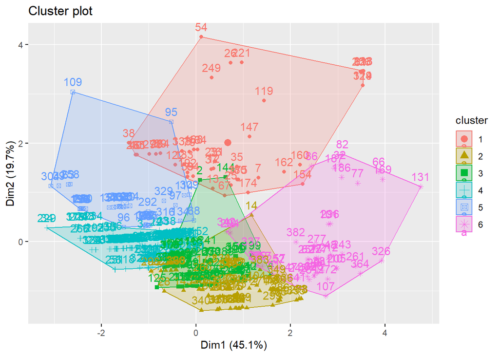

```r
# Plot out the kmeans cluster
fviz_cluster(list(data = corona[, c(59, 98, 270, 309, 311)], cluster = corona_kmeans_cluster))
```

```r
hungary = cvbase %>% filter(coded_country == "Hungary")
hungary <- subset(hungary, select = -c(rankOrdLife_1, rankOrdLife_2, rankOrdLife_3, rankOrdLife_4, rankOrdLife_5, rankOrdLife_6, coded_country, employment_status, corona_close))

# Linear Model
hungary_lm_1 <- lm(c19ProSo01 ~., data = hungary)
# Best Predictors
# c19ProSo01
c19ProSo01_coefficients <- summary(hungary_lm_1)$coefficients
c19ProSo01_significant_predictors <- c19ProSo01_coefficients[c19ProSo01_coefficients[, "Pr(>|t|)"] < 0.05, ]
c19ProSo01_best_predictors <- c19ProSo01_significant_predictors[order(abs(c19ProSo01_significant_predictors[, "Pr(>|t|)"]), decreasing = FALSE), ]
c19ProSo01_best_predictors[1:2, ]
```

```
##             Estimate Std. Error  t value     Pr(>|t|)
## c19ProSo02 0.3686228 0.04926850 7.481916 1.110286e-12
## c19ProSo03 0.2511636 0.05065207 4.958606 1.277359e-06
```

```r
# Plot responses from Hungary
hungary_plot_1 <- qplot(seq_along(hungary$c19ProSo01), hungary$c19ProSo01, main = "Participants Responses for c19ProSo01 for Hungary", xlab = "c19ProSo01", ylab = "c19ProSo01") + geom_smooth(method = "loess", formula = y ~ x, na.rm = TRUE)
# c19ProSo02
hungary_lm_2 <- lm(c19ProSo02 ~., data = hungary)
c19ProSo02_coefficients <- summary(hungary_lm_2)$coefficients
c19ProSo02_significant_predictors <- c19ProSo02_coefficients[c19ProSo02_coefficients[, "Pr(>|t|)"] < 0.05, ]
c19ProSo02_best_predictors <- c19ProSo02_significant_predictors[order(abs(c19ProSo02_significant_predictors[, "Pr(>|t|)"]), decreasing = FALSE), ]
c19ProSo01_best_predictors[1:2, ]
```

```
##             Estimate Std. Error  t value     Pr(>|t|)
## c19ProSo02 0.3686228 0.04926850 7.481916 1.110286e-12
## c19ProSo03 0.2511636 0.05065207 4.958606 1.277359e-06
```

```r
hungary_plot_2 <- qplot(seq_along(hungary$c19ProSo02), hungary$c19ProSo02, main = "Participants Responses for c19ProSo02 for Hungary", xlab = "c19ProSo02", ylab = "c19ProSo02") + geom_smooth(method = "loess", formula = y ~ x, na.rm = TRUE)

# c19ProSo03
hungary_lm_3 <- lm(c19ProSo03 ~., data = hungary)
c19ProSo03_coefficients <- summary(hungary_lm_3)$coefficients
c19ProSo03_significant_predictors <- c19ProSo03_coefficients[c19ProSo03_coefficients[, "Pr(>|t|)"] < 0.05, ]
c19ProSo03_best_predictors <- c19ProSo03_significant_predictors[order(abs(c19ProSo03_significant_predictors[, "Pr(>|t|)"]), decreasing = FALSE), ]
c19ProSo03_best_predictors[1:2, ]
```

```
##             Estimate Std. Error  t value     Pr(>|t|)
## c19ProSo01 0.3415897 0.06888826 4.958606 1.277359e-06
## c19ProSo04 0.2873640 0.06051383 4.748733 3.373682e-06
```

```r
hungary_plot_3 <- qplot(seq_along(hungary$c19ProSo03), hungary$c19ProSo03, main = "Participants Responses for c19ProSo03 for Hungary", xlab = "c19ProSo03", ylab = "c19ProSo03") + geom_smooth(method = "loess", formula = y ~ x, na.rm = TRUE)

# c19ProSo04
hungary_lm_4 <- lm(c19ProSo04 ~., data = hungary)
c19ProSo04_coefficients <- summary(hungary_lm_4)$coefficients
c19ProSo04_significant_predictors <- c19ProSo04_coefficients[c19ProSo04_coefficients[, "Pr(>|t|)"] < 0.05, ]
c19ProSo04_best_predictors <- c19ProSo04_significant_predictors[order(abs(c19ProSo04_significant_predictors[, "Pr(>|t|)"]), decreasing = FALSE), ]
c19ProSo04_best_predictors[1:2, ]
```

```
##             Estimate Std. Error  t value     Pr(>|t|)
## c19ProSo03 0.2757806 0.05807458 4.748733 3.373682e-06
## c19ProSo01 0.1829573 0.06967026 2.626046 9.146617e-03
```

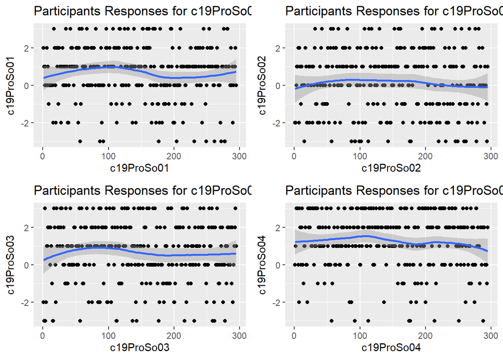

```r
hungary_plot_4 <- qplot(seq_along(hungary$c19ProSo04), hungary$c19ProSo04, main = "Participants Responses for c19ProSo04 for Hungary", xlab = "c19ProSo04", ylab = "c19ProSo04") + geom_smooth(method = "loess", formula = y ~ x, na.rm = TRUE)

ggarrange(hungary_plot_1, hungary_plot_2, hungary_plot_3, hungary_plot_4, ncol = 2, nrow = 2)
```

For c19ProSo01, participants from Hungary responses fluctuated between 0 and 1, which means that most participants from Hungary either “Neither agree nor disagree” or “Somewhat agree” to the statement that “I am willing to help others who suffer from coronavirus.”

For c19ProSo02, participants from Hungary responded 0, which means that most participants from Hungary “Neither agree nor disagree” to the statement that “I am willing to make donations to help others that suffer from coronavirus.”

For c19ProSo03, participants from Hungary responses fluctuated between 0 and 1, which means that most participants from Hungary either “Neither agree nor disagree” or “Somewhat agree” to the statement that “I am willing to protect vulnerable groups from coronavirus even at my own expense.”

For c19ProSo04, participants from Hungary responses fluctuated between 1 and 2, which means that most participants from Hungary either “Somewhat agree” or “Agree” to the statement that “I am willing to make personal sacrifices to prevent the spread of coronavirus.”

```r
iran = cvbase %>% filter(coded_country == "Iran")
iran <- subset(iran, select = -c(rankOrdLife_1, rankOrdLife_2, rankOrdLife_3, rankOrdLife_4, rankOrdLife_5, rankOrdLife_6, coded_country, employment_status, corona_close))

iran_lm_1 <- lm(c19ProSo01 ~., data = iran)
c19ProSo01_coefficients <- summary(iran_lm_1)$coefficients
c19ProSo01_significant_predictors <- c19ProSo01_coefficients[c19ProSo01_coefficients[, "Pr(>|t|)"] < 0.05, ]
c19ProSo01_best_predictors <- c19ProSo01_significant_predictors[order(abs(c19ProSo01_significant_predictors[, "Pr(>|t|)"]), decreasing = FALSE), ]
c19ProSo01_best_predictors[1:2, ]
```

```
##           Estimate Std. Error   t value    Pr(>|t|)
## consp02 -0.3550268  0.1057367 -3.357651 0.001033475
## age      0.2486805  0.1012302  2.456585 0.015355829
```

```r
iran_plot_1 <- qplot(seq_along(iran$c19ProSo01), iran$c19ProSo01, main = "Participants Responses for c19ProSo01 for Iran", xlab = "c19ProSo01", ylab = "c19ProSo01") + geom_smooth(method = "loess", formula = y ~ x, na.rm = TRUE)

iran_lm_2 <- lm(c19ProSo02 ~., data = iran)
c19ProSo02_coefficients <- summary(iran_lm_2)$coefficients
c19ProSo02_significant_predictors <- c19ProSo02_coefficients[c19ProSo02_coefficients[, "Pr(>|t|)"] < 0.05, ]
c19ProSo02_best_predictors <- c19ProSo02_significant_predictors[order(abs(c19ProSo02_significant_predictors[, "Pr(>|t|)"]), decreasing = FALSE), ]
c19ProSo02_best_predictors[1:2, ]
```

```
##             Estimate Std. Error   t value     Pr(>|t|)
## c19ProSo03 0.7540213 0.06181530 12.197973 3.103176e-23
## consp02    0.2008956 0.07588172  2.647484 9.120422e-03
```

```r
iran_plot_2 <- qplot(seq_along(iran$c19ProSo02), iran$c19ProSo02, main = "Participants Responses for c19ProSo02 for Iran", xlab = "c19ProSo02", ylab = "c19ProSo02") + geom_smooth(method = "loess", formula = y ~ x, na.rm = TRUE)

iran_lm_3 <- lm(c19ProSo03 ~., data = iran)
c19ProSo03_coefficients <- summary(iran_lm_3)$coefficients
c19ProSo03_significant_predictors <- c19ProSo03_coefficients[c19ProSo03_coefficients[, "Pr(>|t|)"] < 0.05, ]
c19ProSo03_best_predictors <- c19ProSo03_significant_predictors[order(abs(c19ProSo03_significant_predictors[, "Pr(>|t|)"]), decreasing = FALSE), ]
c19ProSo03_best_predictors[1:2, ]
```

```
##                   Estimate Std. Error   t value     Pr(>|t|)
## c19ProSo02       0.7103530 0.05823534 12.197973 3.103176e-23
## isoOthPpl_online 0.1010448 0.03942672  2.562851 1.152980e-02
```

```r
iran_plot_3 <- qplot(seq_along(iran$c19ProSo03), iran$c19ProSo03, main = "Participants Responses for c19ProSo03 for Iran", xlab = "c19ProSo03", ylab = "c19ProSo03") + geom_smooth(method = "loess", formula = y ~ x, na.rm = TRUE)

iran_lm_4 <- lm(c19ProSo04 ~., data = iran)
c19ProSo04_coefficients <- summary(iran_lm_4)$coefficients
c19ProSo04_significant_predictors <- c19ProSo04_coefficients[c19ProSo04_coefficients[, "Pr(>|t|)"] < 0.05, ]
c19ProSo04_best_predictors <- c19ProSo04_significant_predictors[order(abs(c19ProSo04_significant_predictors[, "Pr(>|t|)"]), decreasing = FALSE), ]
c19ProSo04_best_predictors[1:2, ]
```

```
##             Estimate Std. Error  t value   Pr(>|t|)
## c19ProSo01 0.2071479 0.08471397 2.445262 0.01582383
## c19ProSo02 0.2890333 0.11995751 2.409464 0.01738797
```

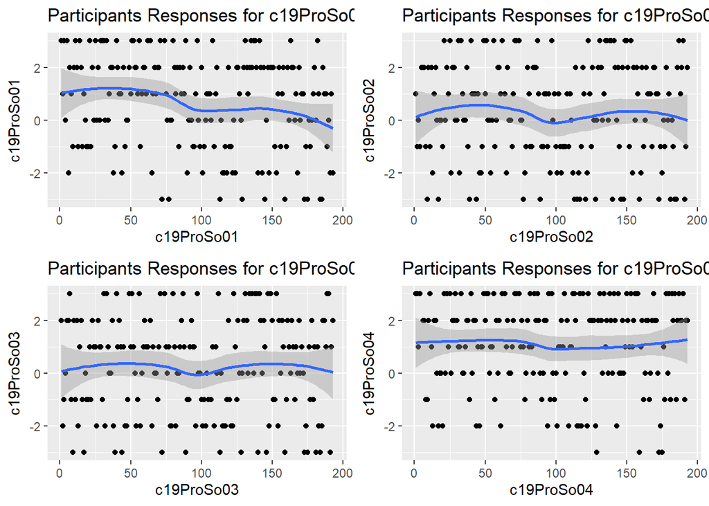

```r
iran_plot_4 <- qplot(seq_along(iran$c19ProSo04), iran$c19ProSo04, main = "Participants Responses for c19ProSo04 for Iran", xlab = "c19ProSo04", ylab = "c19ProSo04") + geom_smooth(method = "loess", formula = y ~ x, na.rm = TRUE)

ggarrange(iran_plot_1, iran_plot_2, iran_plot_3, iran_plot_4, ncol = 2, nrow = 2)
```

For c19ProSo01, participants from Iran responses fluctuated between 0 and 1, which means that most participants from Iran either “Neither agree nor disagree” or “Somewhat agree” to the statement that “I am willing to help others who suffer from coronavirus.”

For c19ProSo02, participants from Iran responded 0, which means that most participants from Iran “Neither agree nor disagree” to the statement that “I am willing to make donations to help others that suffer from coronavirus.”

For c19ProSo03, participants from Iran responded 0 which means that most participants from Iran “Neither agree nor disagree” to the statement that “I am willing to protect vulnerable groups from coronavirus even at my own expense.”

For c19ProSo04, participants from Iran responded 1, which means that most participants from Iran “Somewhat agree” to the statement that “I am willing to make personal sacrifices to prevent the spread of coronavirus.”

### Best Predictors for Iran:

- The best predictor for c19ProSo01 is consp02 with a p-value of 0.001033475 which is less than 0.05.
- The best predictor for c19ProSo02 is c19ProSo03 with a p-value of 3.103176e-23 which is less than 0.05.
- The best predictor for c19ProSo03 is c19ProSo02 with a p-value of 3.103176e-23 which is less than 0.05.
- The best predictor for c19ProSo04 is c19ProSo01 with a p-value of 0.01582383 which is less than 0.05.

```r
philippines = cvbase %>% filter(coded_country == "Philippines")
philippines <- subset(philippines, select = -c(rankOrdLife_1, rankOrdLife_2, rankOrdLife_3, rankOrdLife_4, rankOrdLife_5, rankOrdLife_6, coded_country, employment_status, corona_close))

philippines_lm_1 <- lm(c19ProSo01 ~., data = philippines)
c19ProSo01_coefficients <- summary(philippines_lm_1)$coefficients
c19ProSo01_significant_predictors <- c19ProSo01_coefficients[c19ProSo01_coefficients[, "Pr(>|t|)"] < 0.05, ]
c19ProSo01_best_predictors <- c19ProSo01_significant_predictors[order(abs(c19ProSo01_significant_predictors[, "Pr(>|t|)"]), decreasing = FALSE), ]
c19ProSo01_best_predictors[1:2, ]
```

```
##             Estimate Std. Error   t value     Pr(>|t|)
## c19ProSo02 0.3403081 0.03307542 10.288852 1.568513e-23
## c19ProSo03 0.2028857 0.02874132  7.059025 3.385106e-12
```

```r
philippines_plot_1 <- qplot(seq_along(philippines$c19ProSo01), philippines$c19ProSo01, main = "Participants Responses for c19ProSo01 for Philippines", xlab = "c19ProSo01", ylab = "c19ProSo01") + geom_smooth(method = "loess", formula = y ~ x, na.rm = TRUE)

philippines_lm_2 <- lm(c19ProSo02 ~., data = philippines)
c19ProSo02_coefficients <- summary(philippines_lm_2)$coefficients
c19ProSo02_significant_predictors <- c19ProSo02_coefficients[c19ProSo02_coefficients[, "Pr(>|t|)"] < 0.05, ]
c19ProSo02_best_predictors <- c19ProSo02_significant_predictors[order(abs(c19ProSo02_significant_predictors[, "Pr(>|t|)"]), decreasing = FALSE), ]
c19ProSo02_best_predictors[1:2, ]
```

```
##             Estimate Std. Error  t value     Pr(>|t|)
## c19ProSo03 0.2857587 0.02668230 10.70967 2.977494e-25
## c19ProSo01 0.3136252 0.03048204 10.28885 1.568513e-23
```

```r
philippines_plot_2 <- qplot(seq_along(philippines$c19ProSo02), philippines$c19ProSo02, main = "Participants Responses for c19ProSo02 for Philippines", xlab = "c19ProSo02", ylab = "c19ProSo02") + geom_smooth(method = "loess", formula = y ~ x, na.rm = TRUE)

philippines_lm_3 <- lm(c19ProSo03 ~., data = philippines)
c19ProSo03_coefficients <- summary(philippines_lm_3)$coefficients
c19ProSo03_significant_predictors <- c19ProSo03_coefficients[c19ProSo03_coefficients[, "Pr(>|t|)"] < 0.05, ]
c19ProSo03_best_predictors <- c19ProSo03_significant_predictors[order(abs(c19ProSo03_significant_predictors[, "Pr(>|t|)"]), decreasing = FALSE), ]
c19ProSo03_best_predictors[1:2, ]
```

```
##             Estimate Std. Error   t value     Pr(>|t|)
## c19ProSo02 0.4010978 0.03745192 10.709672 2.977494e-25
## c19ProSo04 0.2349850 0.03040284  7.729046 2.934349e-14
```

```r
philippines_plot_3 <- qplot(seq_along(philippines$c19ProSo03), philippines$c19ProSo03, main = "Participants Responses for c19ProSo03 for Philippines", xlab = "c19ProSo03", ylab = "c19ProSo03") + geom_smooth(method = "loess", formula = y ~ x, na.rm = TRUE)

philippines_lm_4 <- lm(c19ProSo04 ~., data = philippines)
c19ProSo04_coefficients <- summary(philippines_lm_4)$coefficients
c19ProSo04_significant_predictors <- c19ProSo04_coefficients[c19ProSo04_coefficients[, "Pr(>|t|)"] < 0.05, ]
c19ProSo04_best_predictors <- c19ProSo04_significant_predictors[order(abs(c19ProSo04_significant_predictors[, "Pr(>|t|)"]), decreasing = FALSE), ]
c19ProSo04_best_predictors[1:2, ]
```

```
##             Estimate Std. Error  t value     Pr(>|t|)
## c19ProSo03 0.2688072 0.03477883 7.729046 2.934349e-14
## c19ProSo01 0.2129773 0.04023628 5.293165 1.516511e-07
```

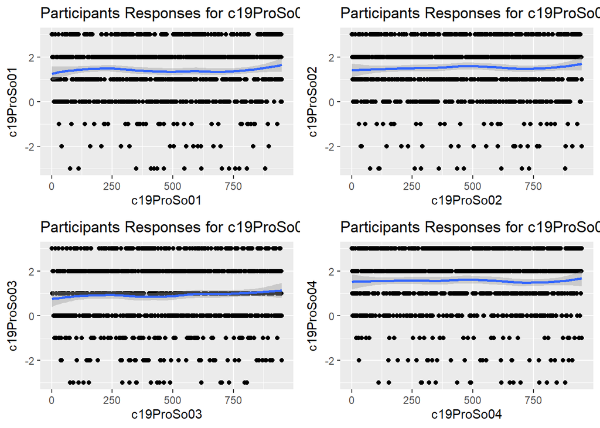

```r
philippines_plot_4 <- qplot(seq_along(philippines$c19ProSo04), philippines$c19ProSo04, main = "Participants Responses for c19ProSo04 for Philippines", xlab = "c19ProSo04", ylab = "c19ProSo04") + geom_smooth(method = "loess", formula = y ~ x, na.rm = TRUE)

ggarrange(philippines_plot_1, philippines_plot_2, philippines_plot_3, philippines_plot_4, ncol = 2, nrow = 2)
```

For c19ProSo01, participants from Philippines responses fluctuated between 1 and 2, which means that most participants from Philippines either “Somewhat agree” or “Agree” to the statement that “I am willing to help others who suffer from coronavirus.”

For c19ProSo02, participants from Philippines responses fluctuated between 1 and 2, which means that most participants from Philippines either “Somewhat agree” or “Agree” to the statement that “I am willing to make donations to help others that suffer from coronavirus.”

For c19ProSo03, participants from Philippines responded 1 which means that most participants from Philippines “Somewhat agree” to the statement that “I am willing to protect vulnerable groups from coronavirus even at my own expense.”

For c19ProSo04, participants from Philippines responses fluctuated between 1 and 2, which means that most participants from Philippines either “Somewhat agree” or “Agree” to the statement that “I am willing to make personal sacrifices to prevent the spread of coronavirus.”

### Best Predictors for Philippines:

- The best predictor for c19ProSo01 is c19ProSo02 with a p-value of 1.568513e-23 which is less than 0.05.
- The best predictor for c19ProSo02 is c19ProSo03 with a p-value of 2.977494e-25 which is less than 0.05.
- The best predictor for c19ProSo03 is c19ProSo02 with a p-value of 2.977494e-25 which is less than 0.05.
- The best predictor for c19ProSo04 is c19ProSo03 with a p-value of 2.934349e-14 which is less than 0.05.

```r
poland = cvbase %>% filter(coded_country == "Poland")
poland <- subset(poland, select = -c(rankOrdLife_1, rankOrdLife_2, rankOrdLife_3, rankOrdLife_4, rankOrdLife_5, rankOrdLife_6, coded_country, employment_status, corona_close))

poland_lm_1 <- lm(c19ProSo01 ~., data = poland)
c19ProSo01_coefficients <- summary(poland_lm_1)$coefficients
c19ProSo01_significant_predictors <- c19ProSo01_coefficients[c19ProSo01_coefficients[, "Pr(>|t|)"] < 0.05, ]
c19ProSo01_best_predictors <- c19ProSo01_significant_predictors[order(abs(c19ProSo01_significant_predictors[, "Pr(>|t|)"]), decreasing = FALSE), ]
c19ProSo01_best_predictors[1:2, ]
```

```
##             Estimate Std. Error  t value     Pr(>|t|)
## c19ProSo03 0.2609982 0.04048517 6.446761 3.262814e-10
## c19ProSo02 0.2136891 0.03589277 5.953540 5.703087e-09
```

```r
poland_plot_1 <- qplot(seq_along(poland$c19ProSo01), poland$c19ProSo01, main = "Participants Responses for c19ProSo01 for Poland", xlab = "c19ProSo01", ylab = "c19ProSo01") + geom_smooth(method = "loess", formula = y ~ x, na.rm = TRUE)

poland_lm_2 <- lm(c19ProSo02 ~., data = poland)
c19ProSo02_coefficients <- summary(poland_lm_2)$coefficients
c19ProSo02_significant_predictors <- c19ProSo02_coefficients[c19ProSo02_coefficients[, "Pr(>|t|)"] < 0.05, ]
c19ProSo02_best_predictors <- c19ProSo02_significant_predictors[order(abs(c19ProSo02_significant_predictors[, "Pr(>|t|)"]), decreasing = FALSE), ]
c19ProSo02_best_predictors[1:2, ]
```

```
##             Estimate Std. Error  t value     Pr(>|t|)
## c19ProSo01 0.3774541 0.06339993 5.953540 5.703087e-09
## edu        0.1641470 0.04658746 3.523417 4.747146e-04
```

```r
poland_plot_2 <- qplot(seq_along(poland$c19ProSo02), poland$c19ProSo02, main = "Participants Responses for c19ProSo02 for Poland", xlab = "c19ProSo02", ylab = "c19ProSo02") + geom_smooth(method = "loess", formula = y ~ x, na.rm = TRUE)

poland_lm_3 <- lm(c19ProSo03 ~., data = poland)
c19ProSo03_coefficients <- summary(poland_lm_3)$coefficients
c19ProSo03_significant_predictors <- c19ProSo03_coefficients[c19ProSo03_coefficients[, "Pr(>|t|)"] < 0.05, ]
c19ProSo03_best_predictors <- c19ProSo03_significant_predictors[order(abs(c19ProSo03_significant_predictors[, "Pr(>|t|)"]), decreasing = FALSE), ]
c19ProSo03_best_predictors[1:2, ]
```

```
##             Estimate Std. Error  t value     Pr(>|t|)
## c19ProSo04 0.4643751 0.04670357 9.943032 5.539451e-21
## c19ProSo01 0.3573870 0.05543667 6.446761 3.262814e-10
```

```r
poland_plot_3 <- qplot(seq_along(poland$c19ProSo03), poland$c19ProSo03, main = "Participants Responses for c19ProSo03 for Poland", xlab = "c19ProSo03", ylab = "c19ProSo03") + geom_smooth(method = "loess", formula = y ~ x, na.rm = TRUE)

poland_lm_4 <- lm(c19ProSo04 ~., data = poland)
c19ProSo04_coefficients <- summary(poland_lm_4)$coefficients
c19ProSo04_significant_predictors <- c19ProSo04_coefficients[c19ProSo04_coefficients[, "Pr(>|t|)"] < 0.05, ]
c19ProSo04_best_predictors <- c19ProSo04_significant_predictors[order(abs(c19ProSo04_significant_predictors[, "Pr(>|t|)"]), decreasing = FALSE), ]
c19ProSo04_best_predictors[1:2, ]
```

```
##             Estimate Std. Error  t value     Pr(>|t|)
## c19ProSo03 0.4233683 0.04257939 9.943032 5.539451e-21
## c19RCA02   0.1762937 0.06408186 2.751070 6.207325e-03
```

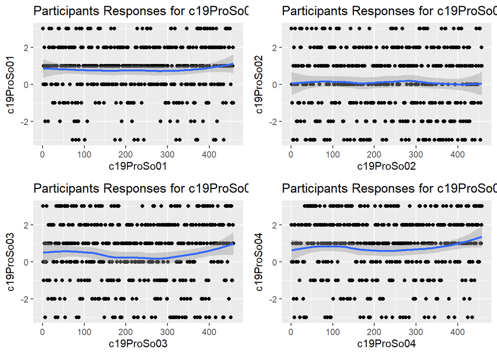

```r
poland_plot_4 <- qplot(seq_along(poland$c19ProSo04), poland$c19ProSo04, main = "Participants Responses for c19ProSo04 for Poland", xlab = "c19ProSo04", ylab = "c19ProSo04") + geom_smooth(method = "loess", formula = y ~ x, na.rm = TRUE)

ggarrange(poland_plot_1, poland_plot_2, poland_plot_3, poland_plot_4, ncol = 2, nrow = 2)
```

For c19ProSo02, participants from Poland responded 0, which means that most participants from Poland “Neither agree nor disagree” to the statement that “I am willing to make donations to help others that suffer from coronavirus.”

For c19ProSo03, participants from Poland responses fluctuated between 0 and 1 which means that most participants from Poland either “Neither agree nor disagree” or “Somewhat agree” to the statement that “I am willing to protect vulnerable groups from coronavirus even at my own expense.”

For c19ProSo04, participants from Poland responses fluctuated around 1, which means that most participants from Poland “Somewhat agree” to the statement that “I am willing to make personal sacrifices to prevent the spread of coronavirus.”

### Best Predictors for Poland:

- The best predictor for c19ProSo01 is c19ProSo03 with a p-value of 3.262814e-10 which is less than 0.05.
- The best predictor for c19ProSo02 is c19ProSo01 with a p-value of 5.703087e-09 which is less than 0.05.
- The best predictor for c19ProSo03 is c19ProSo04 with a p-value of 5.539451e-21 which is less than 0.05.
- The best predictor for c19ProSo04 is c19ProSo03 with a p-value of 5.539451e-21 which is less than 0.05.

```r
saudi_arabia = cvbase %>% filter(coded_country == "Saudi Arabia")
saudi_arabia <- subset(saudi_arabia, select = -c(rankOrdLife_1, rankOrdLife_2, rankOrdLife_3, rankOrdLife_4, rankOrdLife_5, rankOrdLife_6, coded_country, employment_status, corona_close))

saudi_arabia_lm_1 <- lm(c19ProSo01 ~., data = saudi_arabia)
c19ProSo01_coefficients <- summary(saudi_arabia_lm_1)$coefficients
c19ProSo01_significant_predictors <- c19ProSo01_coefficients[c19ProSo01_coefficients[, "Pr(>|t|)"] < 0.05, ]
c19ProSo01_best_predictors <- c19ProSo01_significant_predictors[order(abs(c19ProSo01_significant_predictors[, "Pr(>|t|)"]), decreasing = FALSE), ]
c19ProSo01_best_predictors[1:2, ]
```

```
##             Estimate Std. Error  t value     Pr(>|t|)
## c19ProSo02 0.3813108 0.04294421 8.879214 4.560679e-18
## c19ProSo04 0.2224086 0.03626050 6.133635 1.363727e-09
```

```r
saudi_arabia_plot_1 <- qplot(seq_along(saudi_arabia$c19ProSo04), saudi_arabia$c19ProSo04, main = "Participants Responses for c19ProSo04 for Saudi Arabia", xlab = "c19ProSo04", ylab = "c19ProSo04") + geom_smooth(method = "loess", formula = y ~ x, na.rm = TRUE)

saudi_arabia_lm_2 <- lm(c19ProSo02 ~., data = saudi_arabia)
c19ProSo02_coefficients <- summary(saudi_arabia_lm_2)$coefficients
c19ProSo02_significant_predictors <- c19ProSo02_coefficients[c19ProSo02_coefficients[, "Pr(>|t|)"] < 0.05, ]
c19ProSo02_best_predictors <- c19ProSo02_significant_predictors[order(abs(c19ProSo02_significant_predictors[, "Pr(>|t|)"]), decreasing = FALSE), ]
c19ProSo02_best_predictors[1:2, ]
```

```
##             Estimate Std. Error  t value     Pr(>|t|)
## c19ProSo03 0.2916364 0.02938128 9.925926 5.998479e-22
## c19ProSo01 0.2404651 0.02708180 8.879214 4.560679e-18
```

```r
saudi_arabia_plot_2 <- qplot(seq_along(saudi_arabia$c19ProSo04), saudi_arabia$c19ProSo04, main = "Participants Responses for c19ProSo04 for Saudi Arabia", xlab = "c19ProSo04", ylab = "c19ProSo04") + geom_smooth(method = "loess", formula = y ~ x, na.rm = TRUE)

saudi_arabia_lm_3 <- lm(c19ProSo03 ~., data = saudi_arabia)
c19ProSo03_coefficients <- summary(saudi_arabia_lm_3)$coefficients
c19ProSo03_significant_predictors <- c19ProSo03_coefficients[c19ProSo03_coefficients[, "Pr(>|t|)"] < 0.05, ]
c19ProSo03_best_predictors <- c19ProSo03_significant_predictors[order(abs(c19ProSo03_significant_predictors[, "Pr(>|t|)"]), decreasing = FALSE), ]
c19ProSo03_best_predictors[1:2, ]
```

```
##             Estimate Std. Error   t value     Pr(>|t|)
## c19ProSo04 0.3600643 0.03128383 11.509597 1.997604e-28
## c19ProSo02 0.3841074 0.03869739  9.925926 5.998479e-22
```

```r
saudi_arabia_plot_3 <- qplot(seq_along(saudi_arabia$c19ProSo04), saudi_arabia$c19ProSo04, main = "Participants Responses for c19ProSo04 for Saudi Arabia", xlab = "c19ProSo04", ylab = "c19ProSo04") + geom_smooth(method = "loess", formula = y ~ x, na.rm = TRUE)

saudi_arabia_lm_4 <- lm(c19ProSo04 ~., data = saudi_arabia)
c19ProSo04_coefficients <- summary(saudi_arabia_lm_4)$coefficients
c19ProSo04_significant_predictors <- c19ProSo04_coefficients[c19ProSo04_coefficients[, "Pr(>|t|)"] < 0.05, ]
c19ProSo04_best_predictors <- c19ProSo04_significant_predictors[order(abs(c19ProSo04_significant_predictors[, "Pr(>|t|)"]), decreasing = FALSE), ]
c19ProSo04_best_predictors[1:2, ]
```

```
##             Estimate Std. Error   t value     Pr(>|t|)
## c19ProSo03 0.4027592 0.03499334 11.509597 1.997604e-28
## c19ProSo01 0.2066336 0.03368861  6.133635 1.363727e-09
```

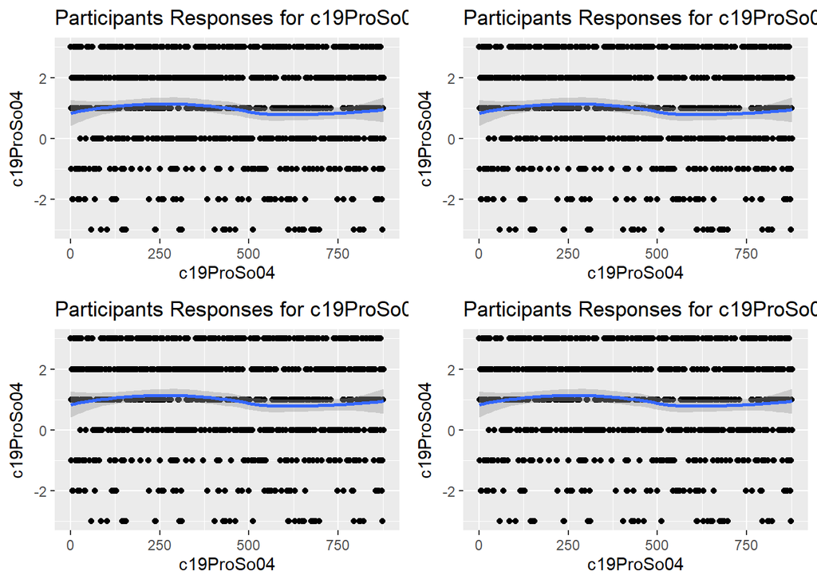

```r
saudi_arabia_plot_4 <- qplot(seq_along(saudi_arabia$c19ProSo04), saudi_arabia$c19ProSo04, main = "Participants Responses for c19ProSo04 for Saudi Arabia", xlab = "c19ProSo04", ylab = "c19ProSo04") + geom_smooth(method = "loess", formula = y ~ x, na.rm = TRUE)

ggarrange(saudi_arabia_plot_1, saudi_arabia_plot_2, saudi_arabia_plot_3, saudi_arabia_plot_4, ncol = 2, nrow = 2)
```

### Best Predictors for Saudi Arabia:

- The best predictor for c19ProSo01 is c19ProSo02 with a p-value of 4.560679e-18 which is less than 0.05.
- The best predictor for c19ProSo02 is c19ProSo03 with a p-value of 5.998479e-22 which is less than 0.05.
- The best predictor for c19ProSo03 is c19ProSo04 with a p-value of 1.997604e-28 which is less than 0.05.
- The best predictor for c19ProSo04 is c19ProSo03 with a p-value of 1.997604e-28 which is less than 0.05.

# Appendix

### Summary of cvbase

```r
summary(cvbase)
```

```
##  isoFriends_inPerson isoOthPpl_inPerson isoFriends_online isoOthPpl_online
##  Min.   :0.000       Min.   :0.000      Min.   :0.000     Min.   :0.00
##  1st Qu.:0.000       1st Qu.:0.000      1st Qu.:2.000     1st Qu.:0.00
##  Median :1.000       Median :1.000      Median :5.000     Median :2.00
##  Mean   :2.074       Mean   :1.952      Mean   :4.414     Mean   :2.87
##  3rd Qu.:4.000       3rd Qu.:3.000      3rd Qu.:7.000     3rd Qu.:5.00
##  Max.   :7.000       Max.   :7.000      Max.   :7.000     Max.   :7.00
##  NA's   :331         NA's   :516        NA's   :949       NA's   :1162
##      lone01          lone02          lone03          happy
##  Min.   :1.000   Min.   :1.000   Min.   :1.000   Min.   : 1.000
##  1st Qu.:1.000   1st Qu.:2.000   1st Qu.:1.000   1st Qu.: 5.000
##  Median :2.000   Median :3.000   Median :2.000   Median : 7.000
##  Mean   :2.422   Mean   :2.667   Mean   :2.084   Mean   : 6.337
##  3rd Qu.:3.000   3rd Qu.:4.000   3rd Qu.:3.000   3rd Qu.: 8.000
##  Max.   :5.000   Max.   :5.000   Max.   :5.000   Max.   :10.000
##  NA's   :86      NA's   :127     NA's   :140     NA's   :514
##     lifeSat           MLQ              bor01             bor02
##  Min.   :1.000   Min.   :-3.0000   Min.   :-3.0000   Min.   :-3.00000
##  1st Qu.:3.000   1st Qu.: 0.0000   1st Qu.:-1.0000   1st Qu.:-2.00000
##  Median :4.000   Median : 1.0000   Median : 0.0000   Median : 0.00000
##  Mean   :4.139   Mean   : 0.8472   Mean   : 0.3251   Mean   : 0.03983
##  3rd Qu.:5.000   3rd Qu.: 2.0000   3rd Qu.: 2.0000   3rd Qu.: 2.00000
##  Max.   :6.000   Max.   : 3.0000   Max.   : 3.0000   Max.   : 3.00000
##  NA's   :111     NA's   :119       NA's   :163       NA's   :176
##      bor03            consp01          consp02          consp03
##  Min.   :-3.0000   Min.   : 0.000   Min.   : 0.000   Min.   : 0.000
##  1st Qu.:-1.0000   1st Qu.: 5.000   1st Qu.: 5.000   1st Qu.: 4.000
##  Median : 0.0000   Median : 7.000   Median : 8.000   Median : 5.000
##  Mean   : 0.3145   Mean   : 6.839   Mean   : 7.163   Mean   : 5.591
##  3rd Qu.: 2.0000   3rd Qu.: 9.000   3rd Qu.: 9.000   3rd Qu.: 8.000
##  Max.   : 3.0000   Max.   :10.000   Max.   :10.000   Max.   :10.000
##  NA's   :177       NA's   :1510     NA's   :1535     NA's   :1555
##  rankOrdLife_1      rankOrdLife_2      rankOrdLife_3      rankOrdLife_4
##  Length:40000       Length:40000       Length:40000       Length:40000
##  Class :character   Class :character   Class :character   Class :character
##  Mode  :character   Mode  :character   Mode  :character   Mode  :character
##
##
##
##
```

[output cut: 25 more lines]

```
##  Min.   :-3.0000   Min.   :-3.0000   Min.   :-3.0000   Min.   :-3.000
##  1st Qu.: 0.0000   1st Qu.: 0.0000   1st Qu.: 0.0000   1st Qu.: 0.000
##  Median : 1.0000   Median : 1.0000   Median : 1.0000   Median : 2.000
##  Mean   : 0.9685   Mean   : 0.6727   Mean   : 0.5469   Mean   : 1.282
##  3rd Qu.: 2.0000   3rd Qu.: 2.0000   3rd Qu.: 2.0000   3rd Qu.: 2.000
##  Max.   : 3.0000   Max.   : 3.0000   Max.   : 3.0000   Max.   : 3.000
##  NA's   :129       NA's   :134       NA's   :149       NA's   :150
##  employment_status  corona_close
##  Length:40000       Length:40000
##  Class :character   Class :character
##  Mode  :character   Mode  :character
##
##
##
##
```

```r
str(cvbase)
```

```
## 'data.frame':    40000 obs. of  38 variables:
##  $ isoFriends_inPerson: int  2 3 4 2 4 7 2 7 3 1 ...
##  $ isoOthPpl_inPerson : int  0 0 3 0 2 4 3 7 3 0 ...
##  $ isoFriends_online  : int  7 0 5 4 3 4 5 7 4 7 ...
##  $ isoOthPpl_online   : int  7 0 0 4 6 0 0 7 0 3 ...
##  $ lone01             : int  3 2 1 3 1 2 2 1 3 2 ...
##  $ lone02             : int  2 2 1 4 1 4 4 1 3 1 ...
##  $ lone03             : int  2 2 1 4 1 3 1 1 2 1 ...
##  $ happy              : int  1 6 10 7 8 2 7 7 6 8 ...
##  $ lifeSat            : int  1 4 6 4 6 2 5 4 4 4 ...
##  $ MLQ                : int  0 2 3 0 3 -2 1 1 -1 -1 ...
##  $ bor01              : int  0 2 -3 0 -2 -1 3 2 0 1 ...
##  $ bor02              : int  -1 1 -3 1 -2 -1 1 2 1 0 ...
##  $ bor03              : int  -1 -1 3 1 3 -1 2 -1 1 -1 ...
##  $ consp01            : int  10 5 8 7 NA 2 3 NA 10 4 ...
```

[output cut: 24 more lines]

### Head of the external csv file

```r
# Take a look of the dataset
head(corona)
```

|  | Country | Year | OVERALL.SCORE | X1..PREVENTION.OF.THE.EMERGENCE.OR.RELEASE.OF.PATHOGENS | X1.1..Antimicrobial.resistance..AMR. | X1.1.1..AMR.surveillance..detection.and.reporting | X1.1.1a..National.plan.for.AMR.priority.pathogens | X1.1.1b..Capacity.of.national.lab.lab.system.to.test.for.AMR.priority.pathogens | X1.1.1c..National.environmental.surveillance.for.AMR.residues.organisms | X1.1.2..Antimicrobial.control | X1.1.2a..National.law.s..requiring.prescription.for.antibiotic.use..humans. | X1.1.2b..National.law.s..requiring.prescription.for.antibiotic.use..animals. | X1.2..Zoonotic.disease | X1.2.1..National.planning.for.zoonotic.diseases.pathogens | X1.2.1a..Laws.plans.on.zoonotic.disease | X1.2.1b..Laws.plans.on.zoonotic.disease.spillover.from.animals.to.humans | X1.2.1c..Laws.plans.for.surveillance...control.of.multiple.zoonotic.pathogens | X1.2.1d..Cross.ministerial.department.agency.unit.for.zoonotic.disease | X1.2.2..Surveillance.systems.for.zoonotic.diseases.pathogens | X1.2.2a..Surveillance.reporting.mechanism.for.zoonotic.disease.for.livestock.owners | X1.2.2b..Laws.regulations.on.data.confidentiality.to.protect.livestock.owners | X1.2.2c..Wildlife.zoonotic.disease.surveillance | X1.2.3..International.reporting.of.animal.disease.outbreaks | X1.2.3a..Annual.reporting.to.OIE.on.zoonotic.disease.incidence | X1.2.4..Animal.health.workforce | X1.2.4a..Number.of.veterinarians.per.100.000.people | X1.2.4b..Number.of.veterinary.para.professionals.per.100.000.people | X1.2.5..Private.sector.and.zoonotic.disease | X1.2.5a..Inclusion.of.private.sector.in.national.plan.law.on.zoonotic.disease | … |
| --- | --- | --- | --- | --- | --- | --- | --- | --- | --- | --- | --- | --- | --- | --- | --- | --- | --- | --- | --- | --- | --- | --- | --- | --- | --- | --- | --- | --- | --- | --- |
| 1 | Afghanistan | 2021 | 28.8 | 12.0 | 16.7 | 33.3 | 50 | 50 | 0 | 0 | 0 | 0 | 5.5 | 25 | 100 | 0 | 0 | 0 | 0.0 | 0 | 0 | 0 | 0 | 0 | 2.7 | 1.3 | 4.1 | 0 | 0 | … |
| 2 | Albania | 2021 | 45.0 | 42.0 | 33.3 | 16.7 | 0 | 50 | 0 | 50 | 100 | 0 | 24.6 | 50 | 100 | 0 | 100 | 0 | 66.7 | 100 | 100 | 0 | 0 | 0 | 6.3 | 12.6 | 0.0 | 0 | 0 | … |
| 3 | Algeria | 2021 | 26.2 | 15.3 | 33.3 | 16.7 | 0 | 50 | 0 | 50 | 100 | 0 | 8.4 | 0 | 0 | 0 | 0 | 0 | 33.3 | 100 | 0 | 0 | 0 | 0 | 8.5 | 17.0 | 0.0 | 0 | 0 | … |
| 4 | Andorra | 2021 | 34.7 | 27.1 | 0.0 | 0.0 | 0 | 0 | 0 | 0 | 0 | 0 | 42.4 | 50 | 100 | 0 | 100 | 0 | 33.3 | 0 | 0 | 100 | 100 | 100 | 28.5 | 25.1 | 32.0 | 0 | 0 | … |
| 5 | Angola | 2021 | 29.1 | 14.7 | 33.3 | 16.7 | 0 | 50 | 0 | 50 | 100 | 0 | 5.1 | 25 | 100 | 0 | 0 | 0 | 0.0 | 0 | 0 | 0 | 0 | 0 | 0.7 | 0.4 | 1.0 | 0 | 0 | … |
| 6 | Antigua & Barbuda | 2021 | 30.0 | 16.7 | 50.0 | 0.0 | 0 | 0 | 0 | 100 | 100 | 100 | 0.0 | 0 | 0 | 0 | 0 | 0 | 0.0 | 0 | 0 | 0 | 0 | 0 | 0.0 | 0.0 | 0.0 | 0 | 0 | … |

### All countries and columns names from the external csv file

```r
# List out all countries
unique(corona$Country)
```

```
##   [1] "Afghanistan"                     "Albania"
##   [3] "Algeria"                         "Andorra"
##   [5] "Angola"                          "Antigua & Barbuda"
##   [7] "Argentina"                       "Armenia"
##   [9] "Australia"                       "Austria"
##  [11] "Azerbaijan"                      "Bahamas"
##  [13] "Bahrain"                         "Bangladesh"
##  [15] "Barbados"                        "Belarus"
##  [17] "Belgium"                         "Belize"
##  [19] "Benin"                           "Bhutan"
##  [21] "Bolivia"                         "Bosnia and Hercegovina"
##  [23] "Botswana"                        "Brazil"
##  [25] "Brunei"                          "Bulgaria"
##  [27] "Burkina Faso"                    "Burundi"
##  [29] "Cabo Verde"                      "Cambodia"
```

[output cut: 83 more lines]

```r
# List out all column names to help identify potential indicators
names(corona)
```

```
##   [1] "Country"
##   [2] "Year"
##   [3] "OVERALL.SCORE"
##   [4] "X1..PREVENTION.OF.THE.EMERGENCE.OR.RELEASE.OF.PATHOGENS"
##   [5] "X1.1..Antimicrobial.resistance..AMR."
##   [6] "X1.1.1..AMR.surveillance..detection.and.reporting"
##   [7] "X1.1.1a..National.plan.for.AMR.priority.pathogens"
##   [8] "X1.1.1b..Capacity.of.national.lab.lab.system.to.test.for.AMR.priority.pathogens"
##   [9] "X1.1.1c..National.environmental.surveillance.for.AMR.residues.organisms"
##  [10] "X1.1.2..Antimicrobial.control"
##  [11] "X1.1.2a..National.law.s..requiring.prescription.for.antibiotic.use..humans."
##  [12] "X1.1.2b..National.law.s..requiring.prescription.for.antibiotic.use..animals."
##  [13] "X1.2..Zoonotic.disease"
##  [14] "X1.2.1..National.planning.for.zoonotic.diseases.pathogens"
##  [15] "X1.2.1a..Laws.plans.on.zoonotic.disease"
```

[output cut: 298 more lines]

### Linear Regression Model Summary for Hungary

```r
# c19ProSo01
summary(hungary_lm_1)
```

```
##
## Call:
## lm(formula = c19ProSo01 ~ ., data = hungary)
##
## Residuals:
##     Min      1Q  Median      3Q     Max
## -3.4128 -0.6822  0.0828  0.8160  2.9709
##
## Coefficients:
##                      Estimate Std. Error t value Pr(>|t|)
## (Intercept)         -0.537065   0.744220  -0.722  0.47115
## isoFriends_inPerson -0.003361   0.035583  -0.094  0.92481
## isoOthPpl_inPerson   0.025086   0.044807   0.560  0.57606
## isoFriends_online   -0.001576   0.036624  -0.043  0.96571
## isoOthPpl_online     0.018149   0.031239   0.581  0.56176
## lone01               0.059990   0.085708   0.700  0.48459
## lone02               0.071697   0.080936   0.886  0.37651
## lone03               0.119393   0.066558   1.794  0.07399 .
## happy                0.083205   0.067669   1.230  0.21995
## lifeSat             -0.099637   0.111948  -0.890  0.37427
## MLQ                  0.035464   0.055372   0.640  0.52243
## bor01               -0.065040   0.060728  -1.071  0.28515
## bor02               -0.050790   0.057352  -0.886  0.37665
## bor03               -0.017900   0.046996  -0.381  0.70359
## consp01              0.010677   0.041670   0.256  0.79797
## consp02             -0.008935   0.049111  -0.182  0.85577
## consp03             -0.014531   0.033621  -0.432  0.66596
## c19perBeh01          0.067436   0.101904   0.662  0.50871
## c19perBeh02          0.006086   0.114513   0.053  0.95765
## c19perBeh03         -0.130814   0.059468  -2.200  0.02870 *
## c19RCA01             0.054025   0.044564   1.212  0.22649
## c19RCA02            -0.172794   0.075222  -2.297  0.02240 *
## c19RCA03             0.100427   0.045425   2.211  0.02791 *
## gender               0.392598   0.207754   1.890  0.05990 .
## age                 -0.010432   0.071696  -0.146  0.88443
## edu                 -0.032338   0.050036  -0.646  0.51866
## c19ProSo02           0.368623   0.049268   7.482 1.11e-12 ***
## c19ProSo03           0.251164   0.050652   4.959 1.28e-06 ***
## c19ProSo04           0.140175   0.053379   2.626  0.00915 **
## ---
## Signif. codes:  0 '***' 0.001 '**' 0.01 '*' 0.05 '.' 0.1 ' ' 1
##
## Residual standard error: 1.182 on 262 degrees of freedom
##   (4 observations deleted due to missingness)
## Multiple R-squared:  0.4288, Adjusted R-squared:  0.3678
## F-statistic: 7.026 on 28 and 262 DF,  p-value: < 2.2e-16
```

```r
# c19ProSo02
summary(hungary_lm_2)
```

```
##
## Call:
## lm(formula = c19ProSo02 ~ ., data = hungary)
##
## Residuals:
##     Min      1Q  Median      3Q     Max
## -3.8149 -0.8350  0.1270  0.8957  4.0590
##
## Coefficients:
##                      Estimate Std. Error t value Pr(>|t|)
## (Intercept)          0.268244   0.847776   0.316 0.751944
## isoFriends_inPerson  0.010136   0.040497   0.250 0.802566
## isoOthPpl_inPerson   0.001412   0.051031   0.028 0.977949
## isoFriends_online    0.066677   0.041483   1.607 0.109185
## isoOthPpl_online     0.024556   0.035548   0.691 0.490316
## lone01              -0.027751   0.097632  -0.284 0.776453
## lone02              -0.042667   0.092224  -0.463 0.644002
## lone03              -0.080953   0.076058  -1.064 0.288143
## happy               -0.062491   0.077148  -0.810 0.418666
## lifeSat              0.169652   0.127185   1.334 0.183394
## MLQ                 -0.059560   0.062969  -0.946 0.345091
## bor01                0.073666   0.069124   1.066 0.287533
## bor02               -0.024513   0.065360  -0.375 0.707926
## bor03                0.003075   0.053507   0.057 0.954213
## consp01              0.011280   0.047431   0.238 0.812207
## consp02             -0.031994   0.055869  -0.573 0.567361
## consp03              0.039227   0.038206   1.027 0.305499
## c19perBeh01          0.020084   0.116081   0.173 0.862770
## c19perBeh02         -0.097068   0.130205  -0.746 0.456636
## c19perBeh03          0.252495   0.066506   3.797 0.000182 ***
## c19RCA01             0.004715   0.050865   0.093 0.926213
## c19RCA02             0.044861   0.086433   0.519 0.604179
## c19RCA03            -0.004902   0.052183  -0.094 0.925229
## gender              -0.997763   0.229961  -4.339 2.05e-05 ***
## age                 -0.024762   0.081595  -0.303 0.761769
## edu                  0.038569   0.056949   0.677 0.498841
## c19ProSo01           0.477579   0.063831   7.482 1.11e-12 ***
## c19ProSo03           0.180631   0.059257   3.048 0.002537 **
## c19ProSo04          -0.123236   0.061079  -2.018 0.044648 *
## ---
## Signif. codes:  0 '***' 0.001 '**' 0.01 '*' 0.05 '.' 0.1 ' ' 1
##
## Residual standard error: 1.345 on 262 degrees of freedom
##   (4 observations deleted due to missingness)
## Multiple R-squared:  0.4203, Adjusted R-squared:  0.3583
## F-statistic: 6.784 on 28 and 262 DF,  p-value: < 2.2e-16
```

```r
# c19ProSo03
summary(hungary_lm_3)
```

```
##
## Call:
## lm(formula = c19ProSo03 ~ ., data = hungary)
##
## Residuals:
##     Min      1Q  Median      3Q     Max
## -4.8815 -0.8505  0.0540  0.9075  3.8196
##
## Coefficients:
##                      Estimate Std. Error t value Pr(>|t|)
## (Intercept)          0.403739   0.868416   0.465  0.64238
## isoFriends_inPerson -0.034106   0.041444  -0.823  0.41130
## isoOthPpl_inPerson   0.007776   0.052283   0.149  0.88188
## isoFriends_online   -0.056233   0.042570  -1.321  0.18767
## isoOthPpl_online    -0.051478   0.036316  -1.418  0.15752
## lone01              -0.109270   0.099818  -1.095  0.27466
## lone02               0.090912   0.094362   0.963  0.33621
## lone03              -0.097374   0.077863  -1.251  0.21220
## happy               -0.017392   0.079136  -0.220  0.82622
## lifeSat             -0.060861   0.130697  -0.466  0.64184
## MLQ                  0.114031   0.064241   1.775  0.07705 .
## bor01                0.111589   0.070640   1.580  0.11538
## bor02                0.018868   0.066974   0.282  0.77838
## bor03               -0.026882   0.054797  -0.491  0.62414
## consp01              0.043358   0.048528   0.893  0.37242
## consp02             -0.022835   0.057260  -0.399  0.69036
## consp03             -0.021492   0.039201  -0.548  0.58398
## c19perBeh01          0.145690   0.118599   1.228  0.22039
## c19perBeh02         -0.042119   0.133521  -0.315  0.75267
## c19perBeh03          0.012258   0.069985   0.175  0.86110
## c19RCA01            -0.043692   0.052046  -0.839  0.40196
## c19RCA02             0.026643   0.088587   0.301  0.76384
## c19RCA03            -0.056126   0.053354  -1.052  0.29379
## gender               0.144932   0.243765   0.595  0.55265
## age                  0.002143   0.083615   0.026  0.97958
## edu                  0.037244   0.058354   0.638  0.52387
## c19ProSo01           0.341590   0.068888   4.959 1.28e-06 ***
## c19ProSo02           0.189617   0.062205   3.048  0.00254 **
## c19ProSo04           0.287364   0.060514   4.749 3.37e-06 ***
## ---
## Signif. codes:  0 '***' 0.001 '**' 0.01 '*' 0.05 '.' 0.1 ' ' 1
##
## Residual standard error: 1.378 on 262 degrees of freedom
##   (4 observations deleted due to missingness)
## Multiple R-squared:  0.3774, Adjusted R-squared:  0.3109
## F-statistic: 5.672 on 28 and 262 DF,  p-value: 4.343e-15
```

```r
# c19ProSo04
summary(hungary_lm_4)
```

```
##
## Call:
## lm(formula = c19ProSo04 ~ ., data = hungary)
##
## Residuals:
##     Min      1Q  Median      3Q     Max
## -4.5427 -0.7955  0.1450  0.8939  2.6945
##
## Coefficients:
##                      Estimate Std. Error t value Pr(>|t|)
## (Intercept)         -1.323534   0.847147  -1.562  0.11941
## isoFriends_inPerson -0.003754   0.040652  -0.092  0.92649
## isoOthPpl_inPerson   0.051247   0.051123   1.002  0.31706
## isoFriends_online    0.034182   0.041788   0.818  0.41412
## isoOthPpl_online     0.052265   0.035566   1.470  0.14289
## lone01               0.047754   0.097965   0.487  0.62634
## lone02              -0.049702   0.092553  -0.537  0.59172
## lone03               0.048399   0.076446   0.633  0.52721
## happy               -0.004001   0.077531  -0.052  0.95888
## lifeSat              0.114235   0.127895   0.893  0.37257
## MLQ                  0.013587   0.063305   0.215  0.83023
## bor01               -0.074513   0.069378  -1.074  0.28380
## bor02                0.037899   0.065578   0.578  0.56381
## bor03               -0.047462   0.053626  -0.885  0.37693
## consp01             -0.013393   0.047605  -0.281  0.77867
## consp02             -0.044769   0.056043  -0.799  0.42511
## consp03              0.034519   0.038365   0.900  0.36908
## c19perBeh01          0.151759   0.116140   1.307  0.19247
## c19perBeh02          0.140805   0.130537   1.079  0.28173
## c19perBeh03          0.139404   0.068021   2.049  0.04142 *
## c19RCA01             0.050217   0.050960   0.985  0.32533
## c19RCA02             0.086538   0.086634   0.999  0.31877
## c19RCA03            -0.078913   0.052150  -1.513  0.13144
## gender               0.069096   0.238924   0.289  0.77266
## age                 -0.072376   0.081790  -0.885  0.37703
## edu                  0.123457   0.056699   2.177  0.03034 *
## c19ProSo01           0.182957   0.069670   2.626  0.00915 **
## c19ProSo02          -0.124152   0.061533  -2.018  0.04465 *
## c19ProSo03           0.275781   0.058075   4.749 3.37e-06 ***
## ---
## Signif. codes:  0 '***' 0.001 '**' 0.01 '*' 0.05 '.' 0.1 ' ' 1
##
## Residual standard error: 1.35 on 262 degrees of freedom
##   (4 observations deleted due to missingness)
## Multiple R-squared:  0.2899, Adjusted R-squared:  0.2141
## F-statistic: 3.821 on 28 and 262 DF,  p-value: 4.652e-09
```

### Linear Regression Model Summary for Iran

```r
# c19ProSo01
summary(iran_lm_1)
```

```
##
## Call:
## lm(formula = c19ProSo01 ~ ., data = iran)
##
## Residuals:
##     Min      1Q  Median      3Q     Max
## -3.5637 -0.6521  0.0318  0.6792  3.2221
##
## Coefficients:
##                      Estimate Std. Error t value Pr(>|t|)
## (Intercept)         -0.940052   1.274946  -0.737  0.46226
## isoFriends_inPerson -0.052906   0.073489  -0.720  0.47288
## isoOthPpl_inPerson  -0.080835   0.076686  -1.054  0.29381
## isoFriends_online    0.095419   0.059628   1.600  0.11199
## isoOthPpl_online    -0.034935   0.058848  -0.594  0.55378
## lone01               0.122141   0.136719   0.893  0.37332
## lone02              -0.203357   0.151838  -1.339  0.18283
## lone03               0.287910   0.148037   1.945  0.05397 .
## happy                0.156337   0.088735   1.762  0.08046 .
## lifeSat              0.021520   0.134231   0.160  0.87288
## MLQ                 -0.222778   0.112597  -1.979  0.05000 *
## bor01                0.172221   0.106753   1.613  0.10913
## bor02               -0.053558   0.113654  -0.471  0.63827
## bor03               -0.115502   0.081769  -1.413  0.16020
## consp01              0.218288   0.091130   2.395  0.01804 *
## consp02             -0.355027   0.105737  -3.358  0.00103 **
## consp03              0.078419   0.044499   1.762  0.08039 .
## c19perBeh01         -0.005881   0.133362  -0.044  0.96489
## c19perBeh02          0.025094   0.206797   0.121  0.90361
## c19perBeh03         -0.072113   0.116577  -0.619  0.53728
## c19RCA01             0.133601   0.137777   0.970  0.33401
## c19RCA02             0.106121   0.119650   0.887  0.37677
## c19RCA03            -0.158816   0.148284  -1.071  0.28616
## gender               0.441586   0.244201   1.808  0.07289 .
## age                  0.248680   0.101230   2.457  0.01536 *
## edu                 -0.129005   0.091120  -1.416  0.15925
## c19ProSo02           0.219329   0.123089   1.782  0.07712 .
## c19ProSo03           0.293931   0.125731   2.338  0.02094 *
## c19ProSo04           0.213847   0.087454   2.445  0.01582 *
## ---
## Signif. codes:  0 '***' 0.001 '**' 0.01 '*' 0.05 '.' 0.1 ' ' 1
##
## Residual standard error: 1.279 on 129 degrees of freedom
##   (35 observations deleted due to missingness)
## Multiple R-squared:  0.585,  Adjusted R-squared:  0.495
## F-statistic: 6.495 on 28 and 129 DF,  p-value: 5.065e-14
```

```r
# c19ProSo02
summary(iran_lm_2)
```

```
##
## Call:
## lm(formula = c19ProSo02 ~ ., data = iran)
##
## Residuals:
##     Min      1Q  Median      3Q     Max
## -3.5325 -0.4252  0.0139  0.3347  4.9936
##
## Coefficients:
##                       Estimate Std. Error t value Pr(>|t|)
## (Intercept)         -0.2901908  0.9024814  -0.322  0.74832
## isoFriends_inPerson  0.0506096  0.0518442   0.976  0.33080
## isoOthPpl_inPerson  -0.0734752  0.0540377  -1.360  0.17630
## isoFriends_online   -0.0600332  0.0422227  -1.422  0.15749
## isoOthPpl_online    -0.0417446  0.0414793  -1.006  0.31611
## lone01               0.0750293  0.0966863   0.776  0.43917
## lone02              -0.0524491  0.1079415  -0.486  0.62786
## lone03              -0.0155143  0.1061250  -0.146  0.88400
## happy                0.0265838  0.0634116   0.419  0.67575
## lifeSat             -0.0207892  0.0948470  -0.219  0.82685
## MLQ                  0.0001555  0.0807653   0.002  0.99847
## bor01               -0.0967371  0.0757172  -1.278  0.20368
## bor02                0.0926709  0.0799684   1.159  0.24866
## bor03               -0.0461478  0.0580860  -0.794  0.42838
## consp01             -0.1364780  0.0647079  -2.109  0.03687 *
## consp02              0.2008956  0.0758817   2.647  0.00912 **
## consp03             -0.0337677  0.0316825  -1.066  0.28850
## c19perBeh01         -0.0868101  0.0939314  -0.924  0.35711
## c19perBeh02          0.0561446  0.1460586   0.384  0.70132
## c19perBeh03          0.0267954  0.0824678   0.325  0.74577
## c19RCA01             0.0166789  0.0977038   0.171  0.86472
## c19RCA02             0.0867918  0.0844636   1.028  0.30608
## c19RCA03            -0.1410430  0.1045151  -1.349  0.17954
## gender              -0.0040061  0.1747389  -0.023  0.98174
## age                 -0.0279067  0.0731477  -0.382  0.70345
## edu                  0.0235847  0.0648553   0.364  0.71671
## c19ProSo01           0.1095245  0.0614657   1.782  0.07712 .
## c19ProSo03           0.7540213  0.0618153  12.198  < 2e-16 ***
## c19ProSo04           0.1489997  0.0618393   2.409  0.01739 *
## ---
## Signif. codes:  0 '***' 0.001 '**' 0.01 '*' 0.05 '.' 0.1 ' ' 1
##
## Residual standard error: 0.9037 on 129 degrees of freedom
##   (35 observations deleted due to missingness)
## Multiple R-squared:  0.8143, Adjusted R-squared:  0.7739
## F-statistic:  20.2 on 28 and 129 DF,  p-value: < 2.2e-16
```

```r
# c19ProSo03
summary(iran_lm_3)
```

```
##
## Call:
## lm(formula = c19ProSo03 ~ ., data = iran)
##
## Residuals:
##     Min      1Q  Median      3Q     Max
## -4.5870 -0.3779  0.1175  0.3867  3.0163
##
## Coefficients:
##                      Estimate Std. Error t value Pr(>|t|)
## (Intercept)          0.125569   0.876240   0.143   0.8863
## isoFriends_inPerson -0.055208   0.050272  -1.098   0.2742
## isoOthPpl_inPerson   0.072229   0.052440   1.377   0.1708
## isoFriends_online    0.023618   0.041249   0.573   0.5679
## isoOthPpl_online     0.101045   0.039427   2.563   0.0115 *
## lone01              -0.135270   0.093307  -1.450   0.1496
## lone02               0.020875   0.104849   0.199   0.8425
## lone03               0.083592   0.102751   0.814   0.4174
## happy               -0.117435   0.060716  -1.934   0.0553 .
## lifeSat              0.085255   0.091770   0.929   0.3546
## MLQ                  0.090597   0.077985   1.162   0.2475
## bor01                0.055338   0.073795   0.750   0.4547
## bor02               -0.111449   0.077402  -1.440   0.1523
## bor03                0.081732   0.056057   1.458   0.1473
## consp01              0.080052   0.063490   1.261   0.2096
## consp02             -0.083176   0.075271  -1.105   0.2712
## consp03             -0.019182   0.030840  -0.622   0.5351
## c19perBeh01          0.041058   0.091401   0.449   0.6540
## c19perBeh02         -0.029125   0.141824  -0.205   0.8376
## c19perBeh03         -0.053113   0.079940  -0.664   0.5076
## c19RCA01             0.054012   0.094724   0.570   0.5695
## c19RCA02            -0.102143   0.081823  -1.248   0.2142
## c19RCA03             0.199283   0.100639   1.980   0.0498 *
## gender              -0.027756   0.169586  -0.164   0.8702
## age                 -0.045716   0.070924  -0.645   0.5203
## edu                  0.002974   0.062981   0.047   0.9624
## c19ProSo01           0.138277   0.059149   2.338   0.0209 *
## c19ProSo02           0.710353   0.058235  12.198   <2e-16 ***
## c19ProSo04           0.040912   0.061252   0.668   0.5054
## ---
## Signif. codes:  0 '***' 0.001 '**' 0.01 '*' 0.05 '.' 0.1 ' ' 1
##
## Residual standard error: 0.8772 on 129 degrees of freedom
##   (35 observations deleted due to missingness)
## Multiple R-squared:  0.8236, Adjusted R-squared:  0.7854
## F-statistic: 21.52 on 28 and 129 DF,  p-value: < 2.2e-16
```

```r
# c19ProSo04
summary(iran_lm_4)
```

```
##
## Call:
## lm(formula = c19ProSo04 ~ ., data = iran)
##
## Residuals:
##     Min      1Q  Median      3Q     Max
## -3.4950 -0.8429  0.0637  0.6127  4.1923
##
## Coefficients:
##                       Estimate Std. Error t value Pr(>|t|)
## (Intercept)         -1.1460182  1.2534033  -0.914   0.3623
## isoFriends_inPerson  0.0721899  0.0721943   1.000   0.3192
## isoOthPpl_inPerson  -0.0002026  0.0757999  -0.003   0.9979
## isoFriends_online    0.0295725  0.0592086   0.499   0.6183
## isoOthPpl_online    -0.0430766  0.0578735  -0.744   0.4580
## lone01              -0.0138495  0.1349708  -0.103   0.9184
## lone02               0.0536090  0.1504018   0.356   0.7221
## lone03              -0.1359245  0.1473354  -0.923   0.3580
## happy               -0.0548411  0.0882463  -0.621   0.5354
## lifeSat              0.1715235  0.1312593   1.307   0.1936
## MLQ                  0.0826761  0.1122522   0.737   0.4628
## bor01               -0.0394522  0.1060653  -0.372   0.7105
## bor02                0.0042714  0.1119556   0.038   0.9696
## bor03                0.0034996  0.0810979   0.043   0.9656
## consp01              0.0844814  0.0913621   0.925   0.3569
## consp02             -0.0908287  0.1082244  -0.839   0.4029
## consp03              0.0241399  0.0442695   0.545   0.5865
## c19perBeh01          0.2055807  0.1300038   1.581   0.1162
## c19perBeh02          0.0644901  0.2034642   0.317   0.7518
## c19perBeh03          0.0916933  0.1146222   0.800   0.4252
## c19RCA01             0.1176021  0.1357004   0.867   0.3878
## c19RCA02            -0.0003563  0.1181193  -0.003   0.9976
## c19RCA03             0.0251999  0.1465732   0.172   0.8638
## gender              -0.1166084  0.2431560  -0.480   0.6324
## age                 -0.0183108  0.1019230  -0.180   0.8577
## edu                  0.1209002  0.0897461   1.347   0.1803
## c19ProSo01           0.2071479  0.0847140   2.445   0.0158 *
## c19ProSo02           0.2890333  0.1199575   2.409   0.0174 *
## c19ProSo03           0.0842398  0.1261222   0.668   0.5054
## ---
## Signif. codes:  0 '***' 0.001 '**' 0.01 '*' 0.05 '.' 0.1 ' ' 1
##
## Residual standard error: 1.259 on 129 degrees of freedom
##   (35 observations deleted due to missingness)
## Multiple R-squared:  0.5449, Adjusted R-squared:  0.4461
## F-statistic: 5.516 on 28 and 129 DF,  p-value: 7.958e-12
```

### Linear Regression Model Summary for Philippines

```r
# c19ProSo01
summary(philippines_lm_1)
```

```
##
## Call:
## lm(formula = c19ProSo01 ~ ., data = philippines)
##
## Residuals:
##     Min      1Q  Median      3Q     Max
## -5.0508 -0.4552  0.0883  0.5464  3.2577
##
## Coefficients:
##                      Estimate Std. Error t value Pr(>|t|)
## (Intercept)         -0.126312   0.311646  -0.405   0.6854
## isoFriends_inPerson  0.034287   0.013435   2.552   0.0109 *
## isoOthPpl_inPerson   0.014853   0.016149   0.920   0.3580
## isoFriends_online   -0.018952   0.014983  -1.265   0.2062
## isoOthPpl_online     0.015074   0.013717   1.099   0.2721
## lone01               0.064874   0.040170   1.615   0.1067
## lone02               0.030553   0.040090   0.762   0.4462
## lone03              -0.093879   0.041910  -2.240   0.0253 *
## happy               -0.005624   0.022611  -0.249   0.8036
## lifeSat             -0.076935   0.039614  -1.942   0.0524 .
## MLQ                  0.049915   0.028138   1.774   0.0764 .
## bor01                0.016562   0.024986   0.663   0.5076
## bor02                0.013738   0.024331   0.565   0.5725
## bor03                0.048516   0.023937   2.027   0.0430 *
## consp01              0.037644   0.016675   2.257   0.0242 *
## consp02             -0.010541   0.016834  -0.626   0.5314
## consp03              0.003004   0.013073   0.230   0.8183
## c19perBeh01         -0.010685   0.053131  -0.201   0.8407
## c19perBeh02          0.155613   0.061507   2.530   0.0116 *
## c19perBeh03         -0.040486   0.041809  -0.968   0.3331
## c19RCA01             0.025666   0.031779   0.808   0.4195
## c19RCA02            -0.014016   0.051728  -0.271   0.7865
## c19RCA03             0.058390   0.038264   1.526   0.1274
## gender               0.049688   0.063437   0.783   0.4337
## age                 -0.056344   0.024735  -2.278   0.0230 *
## edu                  0.035255   0.028811   1.224   0.2214
## c19ProSo02           0.340308   0.033075  10.289  < 2e-16 ***
## c19ProSo03           0.202886   0.028741   7.059 3.39e-12 ***
## c19ProSo04           0.143927   0.027191   5.293 1.52e-07 ***
## ---
## Signif. codes:  0 '***' 0.001 '**' 0.01 '*' 0.05 '.' 0.1 ' ' 1
##
## Residual standard error: 0.9448 on 886 degrees of freedom
##   (35 observations deleted due to missingness)
## Multiple R-squared:  0.4566, Adjusted R-squared:  0.4394
## F-statistic: 26.58 on 28 and 886 DF,  p-value: < 2.2e-16
```

```r
# c19ProSo02
summary(philippines_lm_2)
```

```
##
## Call:
## lm(formula = c19ProSo02 ~ ., data = philippines)
##
## Residuals:
##     Min      1Q  Median      3Q     Max
## -3.9843 -0.4184  0.0260  0.5432  3.3934
##
## Coefficients:
##                       Estimate Std. Error t value Pr(>|t|)
## (Intercept)         -0.2814730  0.2990572  -0.941   0.3469
## isoFriends_inPerson -0.0114959  0.0129393  -0.888   0.3745
## isoOthPpl_inPerson  -0.0142390  0.0155030  -0.918   0.3586
## isoFriends_online    0.0304160  0.0143602   2.118   0.0344 *
## isoOthPpl_online    -0.0050695  0.0131764  -0.385   0.7005
## lone01               0.0054583  0.0386191   0.141   0.8876
## lone02               0.0551865  0.0384540   1.435   0.1516
## lone03              -0.0824222  0.0402518  -2.048   0.0409 *
## happy                0.0335277  0.0216784   1.547   0.1223
## lifeSat              0.0930807  0.0379821   2.451   0.0145 *
## MLQ                  0.0254954  0.0270464   0.943   0.3461
## bor01               -0.0391016  0.0239560  -1.632   0.1030
## bor02                0.0134780  0.0233577   0.577   0.5641
## bor03               -0.0014918  0.0230321  -0.065   0.9484
## consp01             -0.0198769  0.0160403  -1.239   0.2156
## consp02              0.0202453  0.0161500   1.254   0.2103
## consp03             -0.0003211  0.0125503  -0.026   0.9796
## c19perBeh01          0.0031294  0.0510063   0.061   0.9511
## c19perBeh02          0.0968775  0.0591697   1.637   0.1019
## c19perBeh03          0.0310043  0.0401440   0.772   0.4401
## c19RCA01            -0.0014693  0.0305187  -0.048   0.9616
## c19RCA02             0.0016777  0.0496603   0.034   0.9731
## c19RCA03             0.0468227  0.0367479   1.274   0.2029
## gender              -0.1371032  0.0607455  -2.257   0.0243 *
## age                 -0.0219086  0.0238032  -0.920   0.3576
## edu                  0.0477125  0.0276352   1.727   0.0846 .
## c19ProSo01           0.3136252  0.0304820  10.289   <2e-16 ***
## c19ProSo03           0.2857587  0.0266823  10.710   <2e-16 ***
## c19ProSo04           0.0311163  0.0264923   1.175   0.2405
## ---
## Signif. codes:  0 '***' 0.001 '**' 0.01 '*' 0.05 '.' 0.1 ' ' 1
##
## Residual standard error: 0.9071 on 886 degrees of freedom
##   (35 observations deleted due to missingness)
## Multiple R-squared:  0.4827, Adjusted R-squared:  0.4663
## F-statistic: 29.52 on 28 and 886 DF,  p-value: < 2.2e-16
```

```r
# c19ProSo03
summary(philippines_lm_3)
```

```
##
## Call:
## lm(formula = c19ProSo03 ~ ., data = philippines)
##
## Residuals:
##     Min      1Q  Median      3Q     Max
## -4.3053 -0.5298  0.1922  0.6276  6.2053
##
## Coefficients:
##                      Estimate Std. Error t value Pr(>|t|)
## (Intercept)         -0.280213   0.354359  -0.791  0.42930
## isoFriends_inPerson  0.020487   0.015321   1.337  0.18152
## isoOthPpl_inPerson  -0.008171   0.018374  -0.445  0.65665
## isoFriends_online    0.032385   0.017021   1.903  0.05742 .
## isoOthPpl_online    -0.008655   0.015609  -0.554  0.57938
## lone01              -0.027060   0.045745  -0.592  0.55431
## lone02              -0.065354   0.045558  -1.435  0.15178
## lone03               0.138314   0.047574   2.907  0.00374 **
## happy               -0.006101   0.025717  -0.237  0.81254
## lifeSat             -0.006020   0.045151  -0.133  0.89396
## MLQ                  0.006841   0.032058   0.213  0.83106
## bor01                0.066559   0.028336   2.349  0.01905 *
## bor02               -0.020404   0.027670  -0.737  0.46105
## bor03               -0.017883   0.027281  -0.656  0.51231
## consp01              0.007578   0.019018   0.398  0.69038
## consp02             -0.035182   0.019114  -1.841  0.06601 .
## consp03              0.016770   0.014858   1.129  0.25933
## c19perBeh01         -0.059865   0.060396  -0.991  0.32185
## c19perBeh02         -0.012007   0.070206  -0.171  0.86424
## c19perBeh03          0.057929   0.047537   1.219  0.22332
## c19RCA01            -0.015740   0.036153  -0.435  0.66339
## c19RCA02            -0.021560   0.058830  -0.366  0.71410
## c19RCA03             0.020148   0.043572   0.462  0.64389
## gender               0.094890   0.072104   1.316  0.18851
## age                 -0.035329   0.028189  -1.253  0.21044
## edu                 -0.036940   0.032772  -1.127  0.25998
## c19ProSo01           0.262447   0.037179   7.059 3.39e-12 ***
## c19ProSo02           0.401098   0.037452  10.710  < 2e-16 ***
## c19ProSo04           0.234985   0.030403   7.729 2.93e-14 ***
## ---
## Signif. codes:  0 '***' 0.001 '**' 0.01 '*' 0.05 '.' 0.1 ' ' 1
##
## Residual standard error: 1.075 on 886 degrees of freedom
##   (35 observations deleted due to missingness)
## Multiple R-squared:  0.4435, Adjusted R-squared:  0.4259
## F-statistic: 25.22 on 28 and 886 DF,  p-value: < 2.2e-16
```

```r
# c19ProSo04
summary(philippines_lm_4)
```

```
##
## Call:
## lm(formula = c19ProSo04 ~ ., data = philippines)
##
## Residuals:
##     Min      1Q  Median      3Q     Max
## -4.5315 -0.5840  0.1037  0.7338  3.5395
##
## Coefficients:
##                      Estimate Std. Error t value Pr(>|t|)
## (Intercept)         -0.205584   0.379075  -0.542  0.58773
## isoFriends_inPerson -0.044794   0.016334  -2.742  0.00622 **
## isoOthPpl_inPerson   0.036451   0.019616   1.858  0.06346 .
## isoFriends_online    0.007661   0.018241   0.420  0.67460
## isoOthPpl_online    -0.012909   0.016692  -0.773  0.43952
## lone01              -0.015196   0.048934  -0.311  0.75622
## lone02               0.054726   0.048749   1.123  0.26191
## lone03              -0.003609   0.051125  -0.071  0.94374
## happy                0.026120   0.027493   0.950  0.34233
## lifeSat             -0.029247   0.048282  -0.606  0.54484
## MLQ                 -0.009518   0.034287  -0.278  0.78140
## bor01                0.010481   0.030399   0.345  0.73034
## bor02               -0.014513   0.029599  -0.490  0.62402
## bor03                0.070441   0.029089   2.422  0.01565 *
## consp01             -0.013334   0.020338  -0.656  0.51224
## consp02              0.012062   0.020478   0.589  0.55599
## consp03             -0.011284   0.015898  -0.710  0.47803
## c19perBeh01          0.188895   0.064320   2.937  0.00340 **
## c19perBeh02         -0.173880   0.074862  -2.323  0.02042 *
## c19perBeh03          0.136399   0.050679   2.691  0.00725 **
## c19RCA01             0.045226   0.038642   1.170  0.24216
## c19RCA02             0.155264   0.062710   2.476  0.01348 *
## c19RCA03            -0.071239   0.046546  -1.530  0.12625
## gender               0.036470   0.077184   0.473  0.63668
## age                  0.056477   0.030117   1.875  0.06109 .
## edu                  0.041264   0.035049   1.177  0.23939
## c19ProSo01           0.212977   0.040236   5.293 1.52e-07 ***
## c19ProSo02           0.049962   0.042537   1.175  0.24049
## c19ProSo03           0.268807   0.034779   7.729 2.93e-14 ***
## ---
## Signif. codes:  0 '***' 0.001 '**' 0.01 '*' 0.05 '.' 0.1 ' ' 1
##
## Residual standard error: 1.149 on 886 degrees of freedom
##   (35 observations deleted due to missingness)
## Multiple R-squared:  0.3143, Adjusted R-squared:  0.2927
## F-statistic: 14.51 on 28 and 886 DF,  p-value: < 2.2e-16
```

### Linear Regression Model Summary for Poland

```r
# c19ProSo01
summary(poland_lm_1)
```

```
##
## Call:
## lm(formula = c19ProSo01 ~ ., data = poland)
##
## Residuals:
##     Min      1Q  Median      3Q     Max
## -4.4518 -0.6726  0.1044  0.7612  2.7087
##
## Coefficients:
##                       Estimate Std. Error t value Pr(>|t|)
## (Intercept)          0.0619394  0.5294751   0.117   0.9069
## isoFriends_inPerson -0.0001390  0.0247658  -0.006   0.9955
## isoOthPpl_inPerson   0.0583424  0.0270508   2.157   0.0316 *
## isoFriends_online    0.0145846  0.0247714   0.589   0.5563
## isoOthPpl_online    -0.0000155  0.0224665  -0.001   0.9994
## lone01              -0.0148865  0.0696908  -0.214   0.8310
## lone02               0.0412552  0.0592717   0.696   0.4868
## lone03               0.0177875  0.0651293   0.273   0.7849
## happy                0.0236868  0.0460780   0.514   0.6075
## lifeSat              0.0402940  0.0726152   0.555   0.5793
## MLQ                  0.0351039  0.0407955   0.860   0.3900
## bor01                0.0085054  0.0417875   0.204   0.8388
## bor02               -0.0485348  0.0432423  -1.122   0.2624
## bor03               -0.0826233  0.0401409  -2.058   0.0402 *
## consp01             -0.0452017  0.0298010  -1.517   0.1301
## consp02              0.0519395  0.0304983   1.703   0.0893 .
## consp03              0.0165675  0.0273899   0.605   0.5456
## c19perBeh01          0.0331601  0.0607165   0.546   0.5853
## c19perBeh02         -0.1458766  0.0644175  -2.265   0.0241 *
## c19perBeh03          0.0291977  0.0335592   0.870   0.3848
## c19RCA01            -0.0323752  0.0303495  -1.067   0.2867
## c19RCA02             0.0371159  0.0578588   0.641   0.5216
## c19RCA03            -0.0007031  0.0401517  -0.018   0.9860
## gender              -0.0573169  0.1469548  -0.390   0.6967
## age                  0.0766131  0.0482090   1.589   0.1128
## edu                 -0.0631875  0.0354486  -1.783   0.0754 .
## c19ProSo02           0.2136891  0.0358928   5.954 5.70e-09 ***
## c19ProSo03           0.2609982  0.0404852   6.447 3.26e-10 ***
## c19ProSo04           0.0918444  0.0442930   2.074   0.0388 *
## ---
## Signif. codes:  0 '***' 0.001 '**' 0.01 '*' 0.05 '.' 0.1 ' ' 1
##
## Residual standard error: 1.14 on 404 degrees of freedom
##   (25 observations deleted due to missingness)
## Multiple R-squared:  0.3718, Adjusted R-squared:  0.3282
## F-statistic: 8.538 on 28 and 404 DF,  p-value: < 2.2e-16
```

```r
# c19ProSo02
summary(poland_lm_2)
```

```
##
## Call:
## lm(formula = c19ProSo02 ~ ., data = poland)
##
## Residuals:
##     Min      1Q  Median      3Q     Max
## -4.2255 -1.0782  0.1504  1.0815  4.1301
##
## Coefficients:
##                      Estimate Std. Error t value Pr(>|t|)
## (Intercept)         -1.717085   0.698506  -2.458 0.014381 *
## isoFriends_inPerson  0.064393   0.032759   1.966 0.050022 .
## isoOthPpl_inPerson  -0.048163   0.036079  -1.335 0.182649
## isoFriends_online    0.018442   0.032924   0.560 0.575687
## isoOthPpl_online    -0.007113   0.029857  -0.238 0.811819
## lone01              -0.060677   0.092578  -0.655 0.512574
## lone02               0.024255   0.078813   0.308 0.758426
## lone03               0.026230   0.086558   0.303 0.762022
## happy                0.022666   0.061250   0.370 0.711534
## lifeSat             -0.029367   0.096535  -0.304 0.761122
## MLQ                 -0.005506   0.054268  -0.101 0.919241
## bor01                0.035958   0.055512   0.648 0.517514
## bor02                0.040492   0.057525   0.704 0.481901
## bor03                0.047082   0.053577   0.879 0.380047
## consp01              0.011723   0.039715   0.295 0.768003
## consp02             -0.033859   0.040644  -0.833 0.405303
## consp03              0.024010   0.036399   0.660 0.509868
## c19perBeh01         -0.006199   0.080724  -0.077 0.938825
## c19perBeh02          0.219335   0.085462   2.566 0.010634 *
## c19perBeh03         -0.037983   0.044604  -0.852 0.394959
## c19RCA01             0.033790   0.040358   0.837 0.402942
## c19RCA02             0.067836   0.076862   0.883 0.377994
## c19RCA03            -0.043600   0.053320  -0.818 0.414002
## gender              -0.059854   0.195324  -0.306 0.759432
## age                  0.074633   0.064165   1.163 0.245456
## edu                  0.164147   0.046587   3.523 0.000475 ***
## c19ProSo01           0.377454   0.063400   5.954  5.7e-09 ***
## c19ProSo03           0.116811   0.056207   2.078 0.038318 *
## c19ProSo04           0.149511   0.058711   2.547 0.011249 *
## ---
## Signif. codes:  0 '***' 0.001 '**' 0.01 '*' 0.05 '.' 0.1 ' ' 1
##
## Residual standard error: 1.516 on 404 degrees of freedom
##   (25 observations deleted due to missingness)
## Multiple R-squared:  0.3217, Adjusted R-squared:  0.2747
## F-statistic: 6.844 on 28 and 404 DF,  p-value: < 2.2e-16
```

```r
# c19ProSo03
summary(poland_lm_3)
```

```
##
## Call:
## lm(formula = c19ProSo03 ~ ., data = poland)
##
## Residuals:
##     Min      1Q  Median      3Q     Max
## -4.4694 -0.6472  0.1660  0.7682  4.1094
##
## Coefficients:
##                       Estimate Std. Error t value Pr(>|t|)
## (Intercept)          0.3455072  0.6193502   0.558   0.5773
## isoFriends_inPerson  0.0020863  0.0289802   0.072   0.9426
## isoOthPpl_inPerson  -0.0020719  0.0318357  -0.065   0.9481
## isoFriends_online   -0.0176009  0.0289861  -0.607   0.5440
## isoOthPpl_online     0.0050068  0.0262885   0.190   0.8490
## lone01               0.1008983  0.0814003   1.240   0.2159
## lone02              -0.0536531  0.0693485  -0.774   0.4396
## lone03              -0.0342548  0.0762006  -0.450   0.6533
## happy                0.0294171  0.0539171   0.546   0.5856
## lifeSat             -0.0821250  0.0849065  -0.967   0.3340
## MLQ                  0.0904262  0.0475694   1.901   0.0580 .
## bor01               -0.0556721  0.0488226  -1.140   0.2548
## bor02                0.0461041  0.0506279   0.911   0.3630
## bor03               -0.0263572  0.0471993  -0.558   0.5769
## consp01              0.0000684  0.0349715   0.002   0.9984
## consp02             -0.0562930  0.0357065  -1.577   0.1157
## consp03             -0.0298711  0.0320310  -0.933   0.3516
## c19perBeh01          0.1222752  0.0708143   1.727   0.0850 .
## c19perBeh02         -0.0607079  0.0757964  -0.801   0.4236
## c19perBeh03         -0.0226724  0.0392907  -0.577   0.5642
## c19RCA01             0.0079215  0.0355620   0.223   0.8238
## c19RCA02            -0.0934903  0.0675794  -1.383   0.1673
## c19RCA03            -0.0310457  0.0469591  -0.661   0.5089
## gender               0.0996675  0.1719236   0.580   0.5624
## age                 -0.0206052  0.0565797  -0.364   0.7159
## edu                  0.0613631  0.0415318   1.477   0.1403
## c19ProSo01           0.3573870  0.0554367   6.447 3.26e-10 ***
## c19ProSo02           0.0905534  0.0435722   2.078   0.0383 *
## c19ProSo04           0.4643751  0.0467036   9.943  < 2e-16 ***
## ---
## Signif. codes:  0 '***' 0.001 '**' 0.01 '*' 0.05 '.' 0.1 ' ' 1
##
## Residual standard error: 1.335 on 404 degrees of freedom
##   (25 observations deleted due to missingness)
## Multiple R-squared:  0.4708, Adjusted R-squared:  0.4341
## F-statistic: 12.83 on 28 and 404 DF,  p-value: < 2.2e-16
```

```r
# c19ProSo04
summary(poland_lm_4)
```

```
##
## Call:
## lm(formula = c19ProSo04 ~ ., data = poland)
##
## Residuals:
##     Min      1Q  Median      3Q     Max
## -3.5891 -0.7387  0.1006  0.7533  3.9810
##
## Coefficients:
##                      Estimate Std. Error t value Pr(>|t|)
## (Intercept)         -0.070887   0.591590  -0.120  0.90468
## isoFriends_inPerson -0.011728   0.027665  -0.424  0.67185
## isoOthPpl_inPerson   0.012094   0.030392   0.398  0.69088
## isoFriends_online    0.022076   0.027668   0.798  0.42539
## isoOthPpl_online     0.012044   0.025095   0.480  0.63153
## lone01              -0.043093   0.077841  -0.554  0.58016
## lone02              -0.092011   0.066107  -1.392  0.16473
## lone03               0.094330   0.072625   1.299  0.19473
## happy               -0.053850   0.051431  -1.047  0.29571
## lifeSat              0.089626   0.081042   1.106  0.26942
## MLQ                 -0.006669   0.045622  -0.146  0.88386
## bor01               -0.017158   0.046684  -0.368  0.71341
## bor02                0.022522   0.048377   0.466  0.64178
## bor03               -0.006898   0.045083  -0.153  0.87847
## consp01              0.016857   0.033381   0.505  0.61386
## consp02             -0.002092   0.034198  -0.061  0.95125
## consp03             -0.011468   0.030612  -0.375  0.70812
## c19perBeh01         -0.003251   0.067864  -0.048  0.96182
## c19perBeh02          0.108276   0.072229   1.499  0.13464
## c19perBeh03          0.094329   0.037237   2.533  0.01168 *
## c19RCA01             0.039733   0.033900   1.172  0.24186
## c19RCA02             0.176294   0.064082   2.751  0.00621 **
## c19RCA03            -0.045351   0.044805  -1.012  0.31206
## gender               0.051491   0.164206   0.314  0.75400
## age                 -0.061078   0.053947  -1.132  0.25823
## edu                 -0.015232   0.039755  -0.383  0.70182
## c19ProSo01           0.114658   0.055295   2.074  0.03875 *
## c19ProSo02           0.105667   0.041494   2.547  0.01125 *
## c19ProSo03           0.423368   0.042579   9.943  < 2e-16 ***
## ---
## Signif. codes:  0 '***' 0.001 '**' 0.01 '*' 0.05 '.' 0.1 ' ' 1
##
## Residual standard error: 1.274 on 404 degrees of freedom
##   (25 observations deleted due to missingness)
## Multiple R-squared:  0.4453, Adjusted R-squared:  0.4069
## F-statistic: 11.58 on 28 and 404 DF,  p-value: < 2.2e-16
```

### Linear Regression Model Summary for Saudi Arabia

```r
# c19ProSo01
summary(saudi_arabia_lm_1)
```

```
##
## Call:
## lm(formula = c19ProSo01 ~ ., data = saudi_arabia)
##
## Residuals:
##     Min      1Q  Median      3Q     Max
## -5.8594 -0.5807  0.1711  0.6790  3.9568
##
## Coefficients:
##                       Estimate Std. Error t value Pr(>|t|)
## (Intercept)         -0.4956397  0.3328395  -1.489   0.1369
## isoFriends_inPerson -0.0258141  0.0193290  -1.336   0.1821
## isoOthPpl_inPerson   0.0387136  0.0238568   1.623   0.1050
## isoFriends_online    0.0162002  0.0236766   0.684   0.4940
## isoOthPpl_online     0.0287673  0.0209157   1.375   0.1694
## lone01               0.0923320  0.0502466   1.838   0.0665 .
## lone02              -0.0841890  0.0499563  -1.685   0.0923 .
## lone03               0.0493910  0.0467846   1.056   0.2914
## happy               -0.0371072  0.0265880  -1.396   0.1632
## lifeSat              0.0464417  0.0528960   0.878   0.3802
## MLQ                  0.0002888  0.0375085   0.008   0.9939
## bor01               -0.0171767  0.0309849  -0.554   0.5795
## bor02               -0.0272151  0.0244200  -1.114   0.2654
## bor03                0.0552106  0.0292643   1.887   0.0596 .
## consp01              0.0327970  0.0226459   1.448   0.1479
## consp02             -0.0237085  0.0225194  -1.053   0.2928
## consp03              0.0017772  0.0176422   0.101   0.9198
## c19perBeh01          0.0690105  0.0483269   1.428   0.1537
## c19perBeh02          0.1328871  0.0624534   2.128   0.0337 *
## c19perBeh03          0.0182985  0.0449993   0.407   0.6844
## c19RCA01             0.0341827  0.0356236   0.960   0.3376
## c19RCA02             0.0352244  0.0527703   0.668   0.5046
## c19RCA03            -0.0486496  0.0507745  -0.958   0.3383
## gender               0.1217558  0.0930248   1.309   0.1910
## age                 -0.0516122  0.0388731  -1.328   0.1847
## edu                 -0.0186443  0.0319841  -0.583   0.5601
## c19ProSo02           0.3813108  0.0429442   8.879  < 2e-16 ***
## c19ProSo03           0.0736609  0.0391743   1.880   0.0604 .
## c19ProSo04           0.2224086  0.0362605   6.134 1.36e-09 ***
## ---
## Signif. codes:  0 '***' 0.001 '**' 0.01 '*' 0.05 '.' 0.1 ' ' 1
##
## Residual standard error: 1.234 on 781 degrees of freedom
##   (67 observations deleted due to missingness)
## Multiple R-squared:  0.444,  Adjusted R-squared:  0.4241
## F-statistic: 22.27 on 28 and 781 DF,  p-value: < 2.2e-16
```

```r
# c19ProSo02
summary(saudi_arabia_lm_2)
```

```
##
## Call:
## lm(formula = c19ProSo02 ~ ., data = saudi_arabia)
##
## Residuals:
##     Min      1Q  Median      3Q     Max
## -3.5220 -0.5447  0.0272  0.5405  2.7697
##
## Coefficients:
##                      Estimate Std. Error t value Pr(>|t|)
## (Intercept)         -0.173157   0.264617  -0.654  0.51307
## isoFriends_inPerson  0.035419   0.015315   2.313  0.02099 *
## isoOthPpl_inPerson  -0.055660   0.018872  -2.949  0.00328 **
## isoFriends_online    0.027872   0.018781   1.484  0.13820
## isoOthPpl_online    -0.009744   0.016626  -0.586  0.55801
## lone01              -0.039931   0.039962  -0.999  0.31801
## lone02              -0.007143   0.039743  -0.180  0.85741
## lone03              -0.036823   0.037156  -0.991  0.32197
## happy               -0.008859   0.021138  -0.419  0.67525
## lifeSat              0.097886   0.041880   2.337  0.01968 *
## MLQ                 -0.015454   0.029781  -0.519  0.60396
## bor01                0.049337   0.024547   2.010  0.04479 *
## bor02               -0.011138   0.019404  -0.574  0.56613
## bor03                0.021560   0.023279   0.926  0.35466
## consp01              0.007114   0.018006   0.395  0.69289
## consp02              0.019131   0.017883   1.070  0.28505
## consp03              0.008731   0.014007   0.623  0.53324
## c19perBeh01          0.051954   0.038382   1.354  0.17626
## c19perBeh02         -0.028415   0.049729  -0.571  0.56789
## c19perBeh03         -0.003205   0.035738  -0.090  0.92856
## c19RCA01             0.026511   0.028290   0.937  0.34899
## c19RCA02            -0.035342   0.041899  -0.844  0.39921
## c19RCA03             0.100498   0.040184   2.501  0.01259 *
## gender              -0.025357   0.073948  -0.343  0.73176
## age                  0.038836   0.030874   1.258  0.20880
## edu                  0.016214   0.025398   0.638  0.52341
## c19ProSo01           0.240465   0.027082   8.879  < 2e-16 ***
## c19ProSo03           0.291636   0.029381   9.926  < 2e-16 ***
## c19ProSo04           0.127409   0.029126   4.374 1.38e-05 ***
## ---
## Signif. codes:  0 '***' 0.001 '**' 0.01 '*' 0.05 '.' 0.1 ' ' 1
##
## Residual standard error: 0.98 on 781 degrees of freedom
##   (67 observations deleted due to missingness)
## Multiple R-squared:  0.5567, Adjusted R-squared:  0.5408
## F-statistic: 35.03 on 28 and 781 DF,  p-value: < 2.2e-16
```

```r
# c19ProSo03
summary(saudi_arabia_lm_3)
```

```
##
## Call:
## lm(formula = c19ProSo03 ~ ., data = saudi_arabia)
##
## Residuals:
##     Min      1Q  Median      3Q     Max
## -4.6445 -0.5925  0.2198  0.6174  3.4117
##
## Coefficients:
##                     Estimate Std. Error t value Pr(>|t|)
## (Intercept)         -0.36108    0.30349  -1.190   0.2345
## isoFriends_inPerson -0.01169    0.01763  -0.663   0.5074
## isoOthPpl_inPerson   0.01521    0.02177   0.699   0.4850
## isoFriends_online   -0.02764    0.02156  -1.282   0.2002
## isoOthPpl_online     0.03527    0.01904   1.852   0.0644 .
## lone01               0.03690    0.04587   0.804   0.4214
## lone02              -0.04275    0.04559  -0.938   0.3487
## lone03               0.02802    0.04266   0.657   0.5114
## happy               -0.02051    0.02425  -0.846   0.3979
## lifeSat              0.00628    0.04823   0.130   0.8964
## MLQ                  0.04145    0.03415   1.214   0.2253
## bor01               -0.03462    0.02822  -1.227   0.2203
## bor02                0.03522    0.02224   1.584   0.1137
## bor03                0.04680    0.02668   1.754   0.0798 .
## consp01              0.01483    0.02066   0.718   0.4729
## consp02             -0.01987    0.02053  -0.968   0.3334
## consp03             -0.01234    0.01607  -0.768   0.4427
## c19perBeh01          0.02130    0.04409   0.483   0.6293
## c19perBeh02          0.01427    0.05708   0.250   0.8027
## c19perBeh03          0.09345    0.04088   2.286   0.0225 *
## c19RCA01             0.01542    0.03248   0.475   0.6352
## c19RCA02             0.07976    0.04802   1.661   0.0972 .
## c19RCA03            -0.03867    0.04628  -0.836   0.4037
## gender               0.07530    0.08483   0.888   0.3750
## age                  0.01236    0.03547   0.348   0.7276
## edu                 -0.02636    0.02914  -0.905   0.3659
## c19ProSo01           0.06118    0.03254   1.880   0.0604 .
## c19ProSo02           0.38411    0.03870   9.926   <2e-16 ***
## c19ProSo04           0.36006    0.03128  11.510   <2e-16 ***
## ---
## Signif. codes:  0 '***' 0.001 '**' 0.01 '*' 0.05 '.' 0.1 ' ' 1
##
## Residual standard error: 1.125 on 781 degrees of freedom
##   (67 observations deleted due to missingness)
## Multiple R-squared:  0.5375, Adjusted R-squared:  0.5209
## F-statistic: 32.42 on 28 and 781 DF,  p-value: < 2.2e-16
```

```r
# c19ProSo04
summary(saudi_arabia_lm_4)
```

```
##
## Call:
## lm(formula = c19ProSo04 ~ ., data = saudi_arabia)
##
## Residuals:
##     Min      1Q  Median      3Q     Max
## -4.4795 -0.6778  0.0889  0.6539  4.7978
##
## Coefficients:
##                       Estimate Std. Error t value Pr(>|t|)
## (Intercept)         -0.1170321  0.3212464  -0.364   0.7157
## isoFriends_inPerson -0.0142923  0.0186452  -0.767   0.4436
## isoOthPpl_inPerson   0.0499473  0.0229645   2.175   0.0299 *
## isoFriends_online   -0.0102641  0.0228254  -0.450   0.6531
## isoOthPpl_online    -0.0028485  0.0201844  -0.141   0.8878
## lone01              -0.0550581  0.0484964  -1.135   0.2566
## lone02               0.0770319  0.0481607   1.599   0.1101
## lone03              -0.0017794  0.0451271  -0.039   0.9686
## happy                0.0600460  0.0255696   2.348   0.0191 *
## lifeSat             -0.0955239  0.0508961  -1.877   0.0609 .
## MLQ                  0.0459903  0.0361164   1.273   0.2033
## bor01               -0.0120558  0.0298686  -0.404   0.6866
## bor02               -0.0022310  0.0235566  -0.095   0.9246
## bor03               -0.0602672  0.0281892  -2.138   0.0328 *
## consp01             -0.0088067  0.0218550  -0.403   0.6871
## consp02             -0.0103927  0.0217183  -0.479   0.6324
## consp03              0.0030332  0.0170048   0.178   0.8585
## c19perBeh01         -0.0197193  0.0466369  -0.423   0.6725
## c19perBeh02         -0.0489461  0.0603466  -0.811   0.4176
## c19perBeh03         -0.0354441  0.0433601  -0.817   0.4139
## c19RCA01             0.0216052  0.0343486   0.629   0.5295
## c19RCA02             0.0209498  0.0508735   0.412   0.6806
## c19RCA03             0.1100056  0.0488110   2.254   0.0245 *
## gender               0.0284476  0.0897576   0.317   0.7514
## age                 -0.0003275  0.0375114  -0.009   0.9930
## edu                  0.0486840  0.0307864   1.581   0.1142
## c19ProSo01           0.2066336  0.0336886   6.134 1.36e-09 ***
## c19ProSo02           0.1877049  0.0429098   4.374 1.38e-05 ***
## c19ProSo03           0.4027592  0.0349933  11.510  < 2e-16 ***
## ---
## Signif. codes:  0 '***' 0.001 '**' 0.01 '*' 0.05 '.' 0.1 ' ' 1
##
## Residual standard error: 1.19 on 781 degrees of freedom
##   (67 observations deleted due to missingness)
## Multiple R-squared:  0.4809, Adjusted R-squared:  0.4623
## F-statistic: 25.84 on 28 and 781 DF,  p-value: < 2.2e-16
```